# **CLASSIFICATION WITH TREE-BASED MODELS**

Papakostas Nikos

2024-03-30

## PROJECT UNDERSTANDING PHASE

In this small practice project, we will perform data analysis in a dataset named ‘PimaIndiansDiabetes2’, that is available with the R package “mlbench”.

The dataset consists of 768 female Indian patients above 21 years old, along with eight(8) individual characteristics(these will serve as our predictor variables), accompanied with the result of each person being diagnosed as positive or negative to diabetes(this will be our target/response variable)

The characteristics are

- pregnant (Number of times pregnant)
- glucose (Plasma glucose concentration in mg/dL)
- pressure (Diastolic blood pressure in mm Hg)
- triceps (Triceps skin fold thickness in mm)
- insulin (2-Hour serum insulin in mu U/ml)
- mass (Body Mass Index)
- pedigree (Special function that calculates ‘diabetes likelihood’ depending on medical family history)
- age (in years)
- diabetes (Factor indicating the diabetes test result as neg or pos)

The objective is to develop a Machine Learning Model capable of predicting an individual’s likelihood of diabetes, based on these specific characteristics. The ultimate goal is to identify factors contributing to a positive diagnosis of diabetes. This knowledge can help in the development of several precaution measures, to prevent in best, or postpone in worst case scenario, this chronic metabolic disorder.

## DATA UNDERSTANDING PHASE

### Data Summary

Loading the dataset and separating the predictor variables from the target variable. Storing them as ‘df’ and ‘diabetes’, respectively. Also creating a new variable named ‘y’, by transforming the categorical target variable to a binary numeric one. This will come in use later on, in the process of building the correlation matrix.

```r
library(mlbench)
library(doParallel)
doParallel::registerDoParallel(cores = 8)
data("PimaIndiansDiabetes2")
df <- PimaIndiansDiabetes2[ , -9]
diabetes <- PimaIndiansDiabetes2[ , 9]
y <- ifelse(diabetes=="pos", 1, 0)
paged_table(df)
```

|  | pregnant | glucose | pressure | triceps | insulin | mass | pedigree | age |
| --- | --- | --- | --- | --- | --- | --- | --- | --- |
| 1 | 6 | 148 | 72 | 35 | NA | 33.6 | 0.627 | 50 |
| 2 | 1 | 85 | 66 | 29 | NA | 26.6 | 0.351 | 31 |
| 3 | 8 | 183 | 64 | NA | NA | 23.3 | 0.672 | 32 |
| 4 | 1 | 89 | 66 | 23 | 94 | 28.1 | 0.167 | 21 |
| 5 | 0 | 137 | 40 | 35 | 168 | 43.1 | 2.288 | 33 |
| 6 | 5 | 116 | 74 | NA | NA | 25.6 | 0.201 | 30 |
| 7 | 3 | 78 | 50 | 32 | 88 | 31.0 | 0.248 | 26 |
| 8 | 10 | 115 | NA | NA | NA | 35.3 | 0.134 | 29 |
| 9 | 2 | 197 | 70 | 45 | 543 | 30.5 | 0.158 | 53 |
| 10 | 8 | 125 | 96 | NA | NA | NA | 0.232 | 54 |

[output cut: 758 more lines]

Checking the proportion of the two classes for the target variable, which are ‘pos’ for positive diagnosis and ‘neg’ for negative diagnosis. Almost 65% of ‘diabetes’ values are ‘neg’, and 35% ‘pos’. We shall check our options about addressing class imbalance at the Data Preparation Phase.

```r
prop.pos <- sum(diabetes == "pos")/nrow(df)
prop.neg <- sum(diabetes == "neg")/nrow(df)
kable(data.frame('Proporion of Positive Class' = prop.pos,
                 'Proportion of Negative Class' = prop.neg))
```

| Proporion.of.Positive.Class | Proportion.of.Negative.Class |
| --- | --- |
| 0.3489583 | 0.6510417 |

Inspecting the structure of the dataset, and extracting basic descriptive statistics for all independent variables

```r
library(modelsummary)
datasummary_skim(df, output = "DT")
```

|  | Unique | Missing Pct. | Mean | SD | Min | Median | Max |
| --- | --- | --- | --- | --- | --- | --- | --- |
| pregnant | 17 | 0 | 3.8 | 3.4 | 0.0 | 3.0 | 17.0 |
| glucose | 136 | 1 | 121.7 | 30.5 | 44.0 | 117.0 | 199.0 |
| pressure | 47 | 5 | 72.4 | 12.4 | 24.0 | 72.0 | 122.0 |
| triceps | 51 | 30 | 29.2 | 10.5 | 7.0 | 29.0 | 99.0 |
| insulin | 186 | 49 | 155.5 | 118.8 | 14.0 | 125.0 | 846.0 |
| mass | 248 | 1 | 32.5 | 6.9 | 18.2 | 32.3 | 67.1 |
| pedigree | 517 | 0 | 0.5 | 0.3 | 0.1 | 0.4 | 2.4 |
| age | 52 | 0 | 33.2 | 11.8 | 21.0 | 29.0 | 81.0 |

What we have at hand is a data frame of 8 predictor variables, all of them numeric. Having a look at the summary, we detect some anomalies present in the data. The minimum value of ‘glucose’ at 44 and for ‘pressure’ at 24, seem unrealistic.

Also noticeable at first glance is the presence of missing values, most of them gathered at the variables ‘insulin’ and ‘triceps’. This issue will be further investigated at a later step.

The next step involves visualizing the features to gain a deeper understanding of the data. We will plot histograms and density plots for each predictor variable to examine their distributions.

### Data Visualization

Preparing the dataset for visualization

```r
library(reshape2)
meltedf <- melt(df)
```

Visualizing how independent variables are distributed via histograms

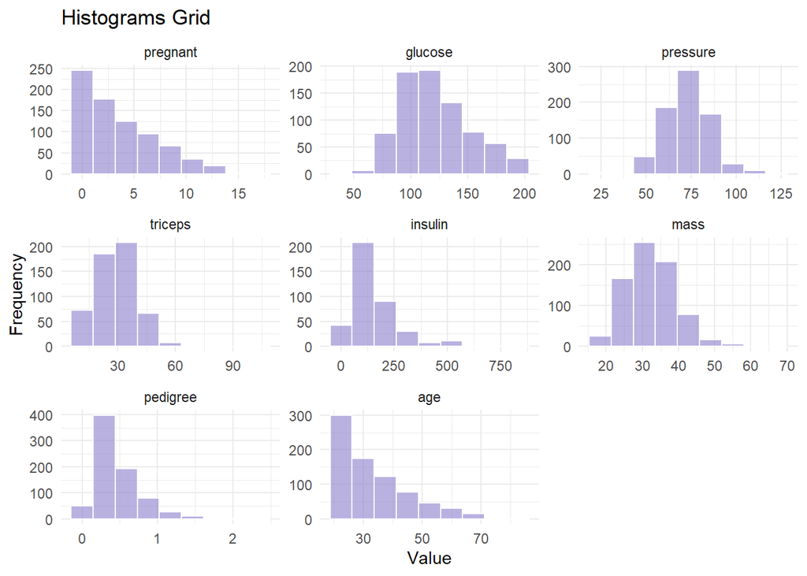

```r
library(ggplot2)
ggplot(meltedf, aes(x = value)) +
 geom_histogram(bins = 9, color = "white",
                fill = "#8A7FCD",
                size = 0.5, alpha = 0.60) +
 facet_wrap(~variable, scales = "free") +
 theme_minimal() +
 labs(title = "Histograms Grid", x = "Value", y = "Frequency")
```

Plotting the densities

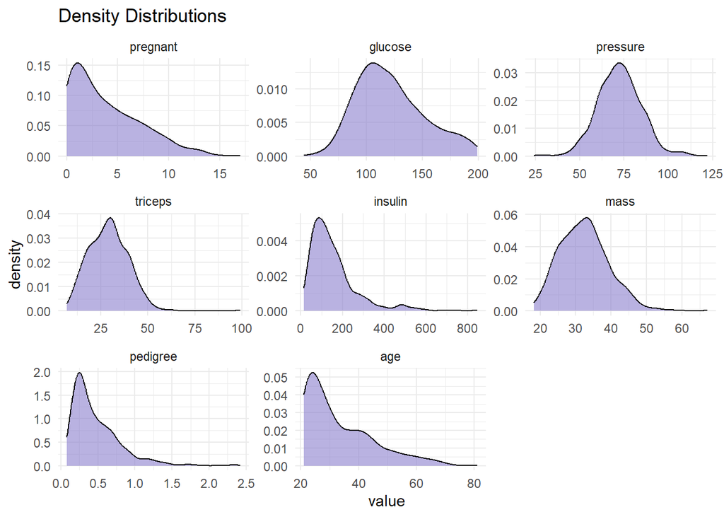

```r
ggplot(meltedf, aes(x = value, fill = variable)) +
  geom_density(adjust = 1, fill = "#8A7FCD", alpha = 0.60) +
  facet_wrap(~variable, scales = "free") +
  theme_minimal() +
  labs(title = "Density Distributions")
```

Viewing the plots gives us a sense of how the variables are distributed. ‘Mass’, ‘pressure’, and ‘triceps’ strongly resemble the Normal Distribution, while ‘age’ and the number of ‘pregnancies’ exhibit positive skewness, indicating a right-skewed distribution. ‘Glucose’ appears to have positive skewness as well. If we decide to apply any type of feature engineering, such as variable transformation or combining existing variables into a new one, the insights gained from these graphs will be valuable. These visualizations can guide our decisions, specifically in the case of a linear regression model where we need to assume normality, and if not, force it, via feature transformation. Another step in Data Understanding Phase is the inspection of any relations, linear or non-linear, simple or complex between the predictors. For the Inspection of co-linearity and multi-colinearity between predictors we proceed with the construction of the correlation matrix, visualizing it via a heatmap, and finally computing its eigenvalues. Given our goal to avoid making strong assumptions and increase uncertainty, we opt for Spearman’s correlation instead of Pearson’s coefficient. Spearman’s correlation is a non-parametric measure that does not assume linearity between the predictors, and checks for monotonic relationships, whether linear or nonlinear.

However, it’s important to acknowledge that the presence of missing values unavoidably introduces uncertainty in our analysis. It is known that correlation coefficients cannot be computed in the presence of missing values. Therefore, in the variables with a big number of NA’s, the true relations may be hidden, especially in this dataset where, as we will see later the ‘missingness’ is very likely to occur Not At Random.

```r
library(ggcorrplot)
correlation_matrix <- round(cor(data.frame(df, diabetes = y), use = "complete.obs",
                               method = "spearman"), 3)
kable(correlation_matrix, caption = 'Correlations Matrix')
```

Correlations Matrix

|  | pregnant | glucose | pressure | triceps | insulin | mass | pedigree | age | diabetes |
| --- | --- | --- | --- | --- | --- | --- | --- | --- | --- |
| pregnant | 1.000 | 0.190 | 0.152 | 0.055 | 0.123 | -0.066 | 0.012 | 0.634 | 0.200 |
| glucose | 0.190 | 1.000 | 0.237 | 0.216 | 0.659 | 0.199 | 0.089 | 0.350 | 0.499 |
| pressure | 0.152 | 0.237 | 1.000 | 0.250 | 0.132 | 0.317 | -0.021 | 0.329 | 0.198 |
| triceps | 0.055 | 0.216 | 0.250 | 1.000 | 0.241 | 0.674 | 0.093 | 0.242 | 0.260 |
| insulin | 0.123 | 0.659 | 0.132 | 0.241 | 1.000 | 0.301 | 0.132 | 0.261 | 0.375 |
| mass | -0.066 | 0.199 | 0.317 | 0.674 | 0.301 | 1.000 | 0.096 | 0.167 | 0.267 |
| pedigree | 0.012 | 0.089 | -0.021 | 0.093 | 0.132 | 0.096 | 1.000 | 0.103 | 0.198 |
| age | 0.634 | 0.350 | 0.329 | 0.242 | 0.261 | 0.167 | 0.103 | 1.000 | 0.397 |
| diabetes | 0.200 | 0.499 | 0.198 | 0.260 | 0.375 | 0.267 | 0.198 | 0.397 | 1.000 |

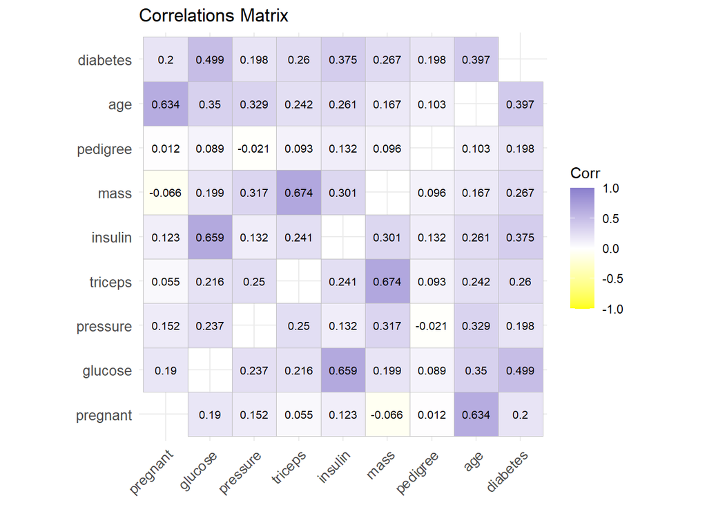

```r
ggcorrplot(correlation_matrix, colors = c("yellow", "white", "#8A7FCD"),
           show.diag = FALSE, lab = TRUE, lab_size = 2.8,
           digits = 3, tl.cex = 10, title = "Correlations Matrix")
```

```r
eigen <- eigen(correlation_matrix)
kable(data.frame(eigenvalues = eigen$values))
```

| eigenvalues |
| --- |
| 3.0536599 |
| 1.4934312 |
| 1.2015018 |
| 0.9852394 |
| 0.7471390 |
| 0.6054105 |
| 0.3460316 |
| 0.3057686 |
| 0.2618181 |

```r
kable(data.frame(kappa = kappa(correlation_matrix)))
```

| kappa |
| --- |
| 11.59594 |

## DATA PREPARATION PHASE

In the Data preparation step we need to check for duplicate records, address the issue of outliers and missing values, and finally prepare the data by splitting it into train and test sets. Also as mentioned above we will not proceed with any feature engineering techniques(e.g. a new variable composition, or a variable transformation).

### Checking for Near Zero Predictors

Moving forward, we must check for near zero variance predictors. A near zero variance predictor can be safely considered as redundant and removed from the dataset before modelling, as it will provide little to no information to our model. In our sample no variable is found as near zero variance, and thus, we proceed using all variables from the set as predictors.

```r
library(caret)
nzv <- nearZeroVar(df, saveMetrics = TRUE)
kable(nzv)
```

|  | freqRatio | percentUnique | zeroVar | nzv |
| --- | --- | --- | --- | --- |
| pregnant | 1.216216 | 2.213542 | FALSE | FALSE |
| glucose | 1.000000 | 17.578125 | FALSE | FALSE |
| pressure | 1.096154 | 5.989583 | FALSE | FALSE |
| triceps | 1.148148 | 6.510417 | FALSE | FALSE |
| insulin | 1.222222 | 24.088542 | FALSE | FALSE |
| mass | 1.083333 | 32.161458 | FALSE | FALSE |
| pedigree | 1.000000 | 67.317708 | FALSE | FALSE |
| age | 1.142857 | 6.770833 | FALSE | FALSE |

### Checking for duplicate records

```r
duplicates <- df[duplicated(df), ]
sum(duplicates)
[1] 0
```

No duplicate records were found in the set.

### Addressing the issue of outliers

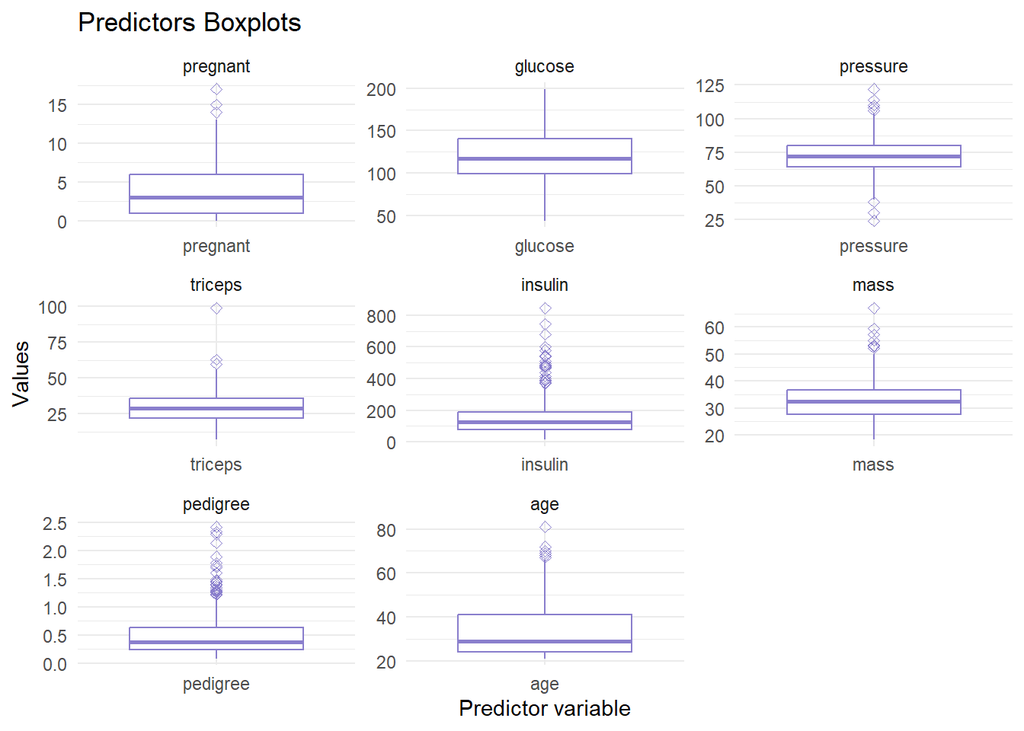

```r
ggplot(meltedf, aes(factor(variable), value)) +
geom_boxplot(outlier.colour = '#8A7FCD', outlier.shape = 05, color = "#8A7FCD",
                                                        fill = "white",) +
  facet_wrap(~variable, scale="free") +
  theme_minimal() +
  labs(title = "Predictors Boxplots", x = "Predictor variable", y = "Values")
```

```r
Pressure_Box <- boxplot(df$pressure, plot = FALSE)
Pressure_Outliers <- Pressure_Box$out
Pressure_Outliers <- subset(df$pressure, df$pressure <= 40)
Pressure_Outliers
[1] 40 30 30 24 38
df$pressure <- ifelse(df$pressure %in% Pressure_Outliers, NA, df$pressure)

Triceps_Box <- boxplot(df$triceps, plot = FALSE)
Triceps_Outliers <- Triceps_Box$out
Triceps_Outliers
[1] 60 63 99
df$triceps <- ifelse(df$triceps %in% Triceps_Outliers, NA, df$triceps)
```

### Addressing the issue of missing values

We already commented on the missing values of the dataset, in the context of outliers but here we move one step forward, and as a first step, we extract descriptive statistics and a simple visualization of their occurrence.

```r
library(naniar)
library(tidyverse)
dim(df)
[1] 768   8
pct_miss(df)
[1] 10.74219
pct_complete(df)
[1] 89.25781
n_miss(df)
[1] 660
n_complete(df)
[1] 5484
kable(miss_var_summary(df))
```

| variable | n_miss | pct_miss |
| --- | --- | --- |
| insulin | 374 | 48.7 |
| triceps | 230 | 29.9 |
| pressure | 40 | 5.21 |
| mass | 11 | 1.43 |
| glucose | 5 | 0.651 |
| pregnant | 0 | 0 |
| pedigree | 0 | 0 |
| age | 0 | 0 |

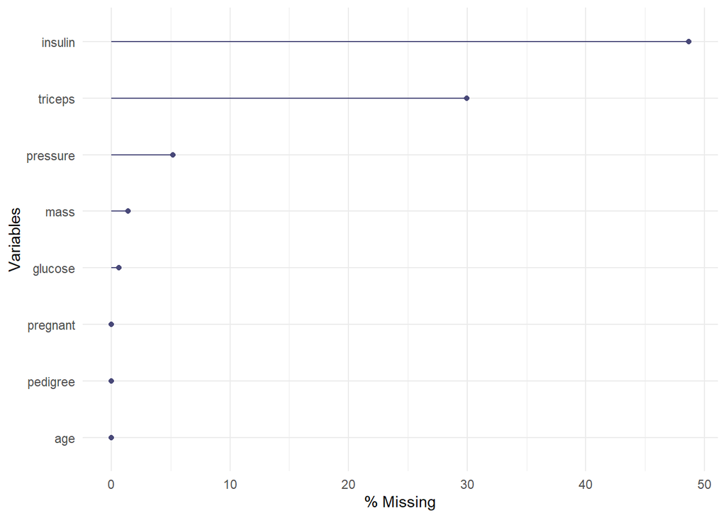

```r
gg_miss_var(df, show_pct = TRUE)
```

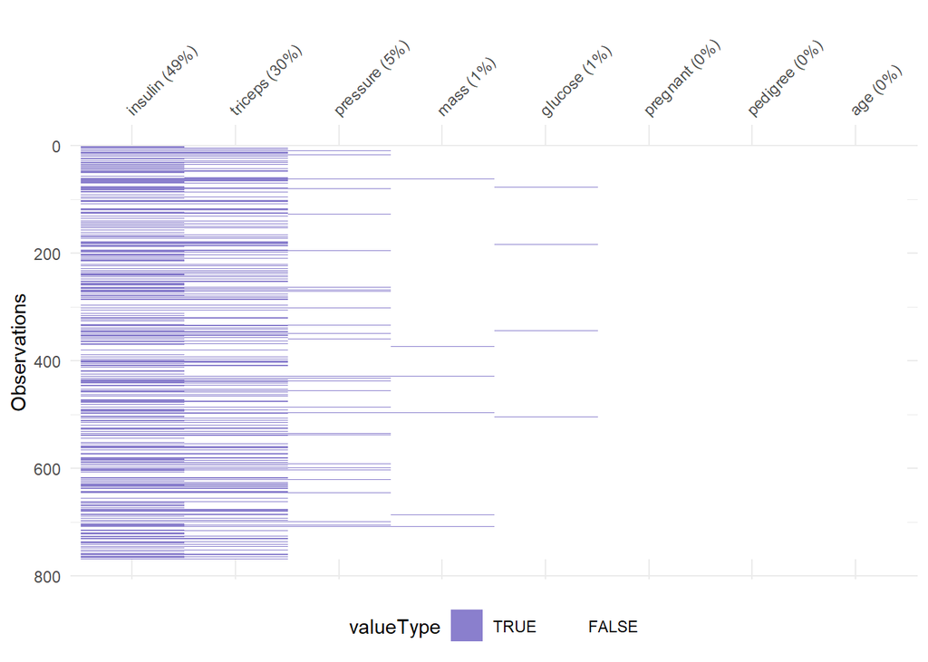

```r
vis_miss(df, sort_miss = TRUE) +
  scale_fill_manual(values = c("white", "#8A7FCD"))
```

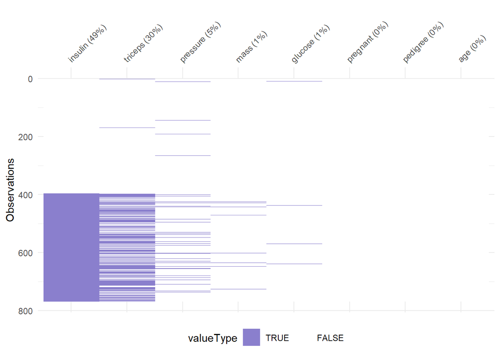

```r
vis_miss(arrange(df, insulin), sort_miss = TRUE) +
  scale_fill_manual(values = c("white", "#8A7FCD"))
```

```r
mcar_test_df <- mcar_test(df)
mcar_test_df
# A tibble: 1 × 4
  statistic    df  p.value missing.patterns
      <dbl> <dbl>    <dbl>            <int>
1      217.    73 3.33e-16               13
```

Missing Not Completely At Random, or Missing Not At Random, is a complex and demanding case

- A simple removal of these records(Complete Case Analysis-CCA), will omit half of the dataset and almost certainly will distort the distributions and bias the resulting model.
- Another approach is to impute the NA’S with parametric statistics such as the mean or the median of the corresponding predictor. However, this method may not be appropriate in the case of missing data not at random (MNAR).
- Non-parametric imputation methods can also be applied, such as ‘knn’(k-nearest neighbors), ‘random forests’, ‘bagged trees’, or semi-parametric methods like ‘pmm’ (predictive mean matching). Many other methods are available, each with its own advantages and risks due to assumptions made.

This is the point in which we have to highlight something that might be misunderstood regarding tree-based models. In general, we can leave the missing values in the data as is, and proceed with the implementation of a decision tree or an ensemble of trees for the classification task. Tree-based models can handle missing values to a reasonable extent, as they adapt to the nature of the data and make decisions on how to handle missing values locally at each node. Based on the available information and without requiring additional assumptions or imputation methods we can build a predictive model with descent performance both in terms of metrics like accuracy, sensitivity etc, as well as in terms of interpretability. But this is only in the case we deal with missing values Completely At Random, the ‘missingness’ extends to a reasonable level, and is spread out to all predictors, rather evenly

In our case, where the missing values seem to happen Not At Random, and additionally, 92% of the total NA’s of the data frame are gathered in two predictors only, relying on the tree model to handle these NA’s will result in distorted predictor importance and interpretation.

Moreover, the number of missing values slightly increased during the process of handling possible outliers, as some values were considered implausible, and converted to NA’s. This particular case will affect a tree-based model as well. For example, in our sample, leaving the NA’s being treated by the tree algorithm will lead to a model that might look ‘good’ in terms of performance metrics, but this is not the case considering the derivations and interpretations of the model. Taking the case of an ensemble of 250 decision trees(bagged trees), you might build a model with an AUC close to 0.90 and accuracy close to 0.85. However, these numbers alone do not capture the full picture, as our final goal extends beyond mere numerical performance metrics. It involves drawing meaningful conclusions from the model.

In terms of interpretation, the model may erroneously indicate ‘insulin’ as a predictor with zero contribution to the formation of diabetes. Fact that of course according to present Domain Knowledge is not true. This is the effect of a variable having more than half of its values missing. In simple terms as more and more trees are built, the algorithm increasingly disregards ‘insulin’, due to its large proportion of NA’s, leading the contribution/importance of ‘insulin’ to vanish.

In such cases, our best choice is to impute the data during the Data Preparation Phase, before modeling, as this will lead to more reliable results and derivations. For the imputation, we will use the mice() function, with the ‘rf’(Random Forest) method. This method is proved to be flexible, robust and reliable while at the same time we are not supposed to make any strong assumptions that have also to be verified. For example we can proceed with other predictive methods for the imputation, like ‘norm’, or ‘pmm’ method, but in this case we have to check for the linearity assumption that has to be met, and if not, we have to force it via feature engineering(e.g. a variable transformation).  
By plotting the original variables ‘insulin’ and ‘triceps’, which ‘suffer’ the most from missing values, along with the imputed distributions, we can gain insight, about how well the imputation approximates the original distribution.

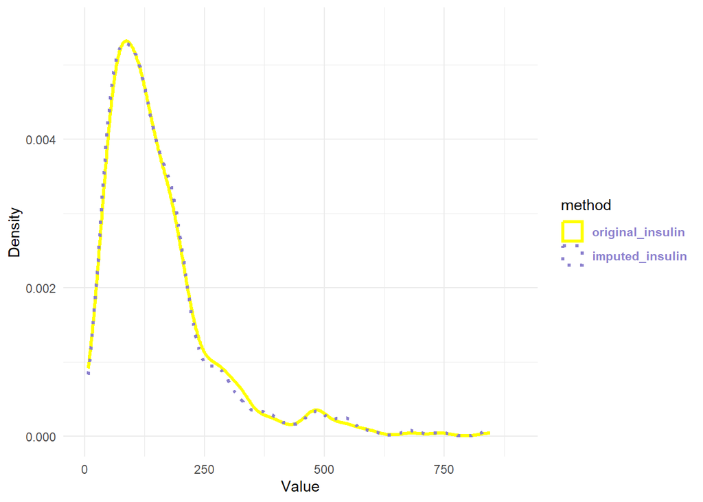

```r
library(mice)
imputed_df <- mice(df, m = 1, method = "rf",  seed = 123, maxit = 3, print = FALSE)
imputed_df <- complete(imputed_df, "all", include = TRUE)
imputed_df <- as.data.frame(imputed_df[2])
imputations <- data.frame(original_insulin = df$insulin,
                          imputed_insulin = imputed_df$X1.insulin,
                          original_triceps = df$triceps,
                          imputed_triceps = imputed_df$X1.triceps)
imputations_long <- gather(imputations, method, value, factor_key = TRUE)

ggplot(imputations_long, aes(x = value, color = method)) +
  geom_density(aes(linetype = method), size = 1.2, na.rm = TRUE) +
  scale_color_manual(values = c("original_insulin" = "yellow",
                                "imputed_insulin" = "#8A7FCD")) +
  scale_linetype_manual(values = c("original_insulin" = "solid",
                                   "imputed_insulin" = "dotted")) +
  labs(x = "Value", y = "Density") +
  coord_cartesian(xlim = c(0, 900), ylim = c(0,0.0055)) +
  theme_minimal() +
  theme(legend.text = element_text(color = "#8A7FCD", face = "bold"))
```

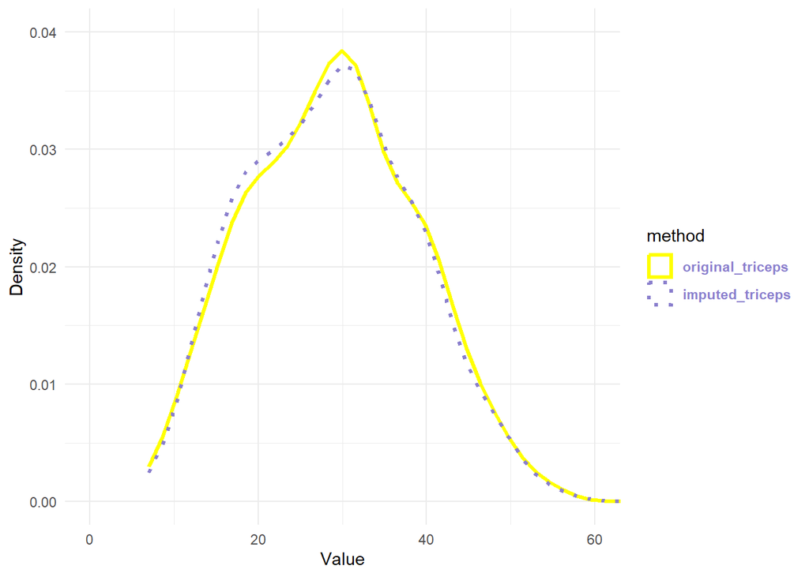

```r
ggplot(imputations_long, aes(x = value, color = method)) +
  geom_density(aes(linetype = method), size = 1.2, na.rm = TRUE) +
  scale_color_manual(values = c("original_triceps" = "yellow",
                                "imputed_triceps" = "#8A7FCD")) +
  scale_linetype_manual(values = c("original_triceps" = "solid",
                                   "imputed_triceps" = "dotted")) +
  labs(x = "Value", y = "Density") +
  coord_cartesian(xlim = c(0, 60), ylim = c(0,0.040)) +
  theme_minimal() +
  theme(legend.text = element_text(color = "#8A7FCD", face = "bold"))
```

From the plot, we see that the ‘rf’ imputation method fits adequately to the original data distribution.

We extract the summary for imputation and compare it with the original data distribution, in case we spot any significant deviations. We also check if the imputed values deviate from the known-established range of values according to Present Domain Knowledge.

```r
datasummary_skim(data.frame(imputed_df$X1.insulin, df$insulin, imputed_df$X1.triceps,
                            df$triceps), output = "DT")
```

|  | Unique | Missing Pct. | Mean | SD | Min | Median | Max |
| --- | --- | --- | --- | --- | --- | --- | --- |
| imputed_df.X1.insulin | 185 | 0 | 156.1 | 123.3 | 14.0 | 125.0 | 846.0 |
| df.insulin | 186 | 49 | 155.5 | 118.8 | 14.0 | 125.0 | 846.0 |
| imputed_df.X1.triceps | 47 | 0 | 28.7 | 9.8 | 7.0 | 29.0 | 56.0 |
| df.triceps | 48 | 30 | 28.9 | 9.9 | 7.0 | 29.0 | 56.0 |

Last move to assess how well the imputation matches the original data, is to perform a non-parametric statistical test. We proceed with ‘Kolmogorov-Smirnov’ test, where the Null Hypothesis is that the imputed distribution is drawn from the original data, or in other words, the imputed distribution has no difference from the original data distribution.

```r
ks.test(df$insulin, imputed_df$X1.insulin, alternative = "two.sided",
                              exact = TRUE,
        simulate.p.value = TRUE)

    Monte-Carlo two-sample Kolmogorov-Smirnov test

data:  df$insulin and imputed_df$X1.insulin
D = 0.013384, p-value = 1
alternative hypothesis: two-sided

ks.test(df$triceps, imputed_df$X1.triceps, alternative = "two.sided",
        exact = TRUE,
        simulate.p.value = TRUE)

    Monte-Carlo two-sample Kolmogorov-Smirnov test

data:  df$triceps and imputed_df$X1.triceps
D = 0.018878, p-value = 0.9915
alternative hypothesis: two-sided
```

The results are promising since for both variables, we fail to reject the null hypothesis.  
That is, the imputed distribution does not significantly differ from the original data. The test statistics, and the p-values from the tests, indicate that the difference in the distributions is minor, and the high p-value allows us to proceed with the imputation, feeling pretty safe.  
*Please note that a mean or median imputation would be inappropriate in this context. A simple plot, comparing the distribution of imputed values against the original data, would make this point obvious.*

### Preparing the datasets

We reach the final step of Data Preparation Phase, where we split the imputed data into a train and a test set. The test set will be kept out and used solely for the evaluation of our model. Since we are working on a dataset with only a few records, a valid choice is the 80-20 split, so as to have ‘enough’ records to train our model, and let it uncover/discover the patterns of the data and the nature of its features.  
We are making sure that the sampling is ‘stratified’ with respect to the target variable ‘diabetes’.  
We have already mentioned the imbalance of the classes for the target variable. Almost 65% of the patients are diagnosed negative to diabetes, and 35% as positive.  
More specifically we have 500 records of ‘negative’ cases, and 268 for positive ones.  
Choosing Undersampling may not be a viable option in our case due to the small size of the dataset. Disregarding a significant portion of the data through undersampling would not only distort the underlying data distribution. and reduce the amount of information available for modeling, but also potentially introduce bias and lead to poor generalization.  
After undersampling we will be left with just 536 records. 268 records for each class of the target variable. Throwing in the garbage 232 records out of a 768 total, seems irrational. On the other hand, choosing to oversample the minority class to balance the target variable also imposes certain challenges.  
Synthetic samples are generated for the minority class to balance the dataset, but these samples may not fully capture the true underlying distribution of the data.  
As a result, there is a risk of introducing bias in the model, particularly if the synthetic samples do not accurately represent the characteristics of the minority.  
Despite its challenges, oversampling the minority class offers several benefits in addressing class imbalance.  
By increasing the representation of the minority class, oversampling ensures that the model receives sufficient training data to learn from the less frequent class, thereby improving its ability to make accurate predictions for both classes.  
Additionally, oversampling helps prevent the model from being biased towards the majority and may enhance its overall performance metrics, such as accuracy, sensitivity, and specificity.  
Furthermore, oversampling techniques like Synthetic Minority Over-sampling Technique (SMOTE) or Adaptive Synthetic Sampling (ADASYN), can generate artificial samples that closely resemble the characteristics of the minority class, thereby minimizing to an extent, the risk of introducing bias or overfit the model.  
We will proceed with modeling, using both the original unbalanced dataset and a balanced(oversampled) one, and observe any differences on the results.  
One very important note on the procedure of the balanced dataset option, is that we will balance only the train set for model training and keep the evaluation/test set intact with the target variable imbalanced.  
By training the model on a balanced dataset and evaluating it on an imbalanced test set, we create a more realistic simulation of how the model will perform in real-world scenarios where class distributions are uneven.  
This approach helps ensure that the model learns to make predictions that generalize well to unseen data with imbalanced class distributions. The final evaluation on ‘unseen’ data reflects the model’s ability to generalize to real-world scenarios, making the evaluation more unbiased and reliable.  
Last move is to create the folds(data splits), to be used for the cross-validation inside the model. Considering the ‘tiny’ size of the sample, 5 folds will be our choice, but keep in mind that in general, for larger datasets a common choice for the number of folds is 10.

```r
library(tidymodels)
library(UBL)
set.seed(123)
df$diabetes <- diabetes
imputed_df$diabetes <- diabetes
colnames(imputed_df) <- colnames(df)
df_split <- initial_split(imputed_df, prop = 4/5, strata = diabetes)
train <- training(df_split)
test <- testing(df_split)
balanced_train <- AdasynClassif(diabetes~., train, beta = 1, k = 3,
                                dist = "Euclidean")
nrow(subset(test, diabetes == "pos"))/nrow(test)
[1] 0.3506494
nrow(subset(train, diabetes == "pos"))/nrow(train)
[1] 0.3485342
nrow(subset(balanced_train, diabetes == "pos"))/nrow(balanced_train)
[1] 0.5067818
nrow(subset(balanced_train, diabetes == "neg"))/nrow(balanced_train)
[1] 0.4932182
folds <- vfold_cv(train, v = 5, strata = diabetes)
balanced_folds <- vfold_cv(balanced_train, v = 5, strata = diabetes)
```

## MODEL & EVALUATION PHASE

### Decision Tree

[Decision tree](https://scikit-learn.org/stable/modules/tree.html#) is a fundamental machine learning technique used for both classification and regression tasks. They operate by recursively partitioning the data into subsets based on the values of the input features in the data that are used as predictors, forming a tree-like structure of decision rules. The root of the tree(root node) initially contains all data elements. Each internal node of the tree represents a decision based on a feature, leading to different branches corresponding to different feature values. At the leaf nodes(the nodes at the bottom of the dendrogram), the model provides its predictions or class labels. Decision trees offer interpretability, as the resulting tree structure can be easily visualized and understood, while they can also handle data inconsistencies to a reasonable extent. Despite their simplicity, decision trees can capture complex relationships in the data and are a popular choice for predictive modeling tasks. However, they are sensitive to over-fitting and high variability. [Tidymodels](https://www.tidymodels.org/) will be our choice for modelling, with the ‘rpart’ algorithm. A small brief about how the ‘rpart’ algorithm operates [RPART](https://cran.r-project.org/web/packages/rpart/rpart.pdf) stands for Recursive Partitioning. The process is a recursive binary splitting of the data in such a way that several criteria/conditions, set by the user are met. - We begin at the root node where all data points/elements of the dataset exist - The algorithm in the initial split searches for the best filtering in any of the predictor variables that splits the set in two groups while at the same time meeting a specific condition/criterion that is set by the user. The user can choose for the split to be made in such a way that the data impurity/data entropy within the 2 formed groups is minimized or moving in the opposite direction but with the same scope, in such a way that the maximum possible information is gained in both subsets.

- The splitting process continues recursively the same way, in both subsets created by the initial split while at the same time, the splitting criterion has to be met.(either the optimal minimization of data entropy or the optimal maximization of information gained).
- The splitting process continues until it is stopped by conditions defined by the user. Such conditions can be the maximum depth of the tree has been reached, or the minimum number of data points/records a node must contain.
- After the process is complete and the tree is fully grown, the algorithm may cut branches that increase the complexity of the tree without significantly improving its performance.
- Using the formed paths from the root to the leaf nodes at the bottom, the model provides its predictions

We use `decision_tree()` function to build the model.  
We set the parameters for the depth of the tree, and the minimum number of records to be contained in a node, to be tuned so as to search in multiple combinations of values, for the search of the best among them, while setting the complexity parameter cp, fixed at 0.02. Adjusting cp parameter helps us to manage the complexity of the tree. Lower levels for the cp parameter will lead to an overgrown tree and larger values to a simpler, pruned tree. Setting the parameter at a reasonable level will result in a more easily interpretable, intuitive tree graph, and less prone to over-fitting. Our algorithm choice will be ‘rpart’ and as the splitting criterion we choose [‘information” gain’](https://homes.cs.washington.edu/~shapiro/EE596/notes/InfoGain.pdf)  
We use a recipe in which we take care of the slight imbalance in the classes of the target variable. We feed the workflow of the process with the model and the recipe, define the folds for the cross-validation process, and the grid of different combinations for the values of the parameters.  
All these are used inside the `tune_grid()` function for the tuning process to be performed and the best model in terms of performance is extracted and fit in the test set for evaluation.  
Setting the argument ‘levels’ to 10 inside the `grid_regular()` function, so as to define how many values of each parameter will be used to produce the grid. Having 2 parameters to tune and 10 possible values for each, results in 100 different possible tuning combinations, from which the model will choose the best, ‘performance wise’. Using `select_best()` extracts the best tuned model in terms of performance and the final model is ready. The process ends with the evaluation of the model. We extract the predictions on the test set, the construction of the confusion matrix, the ROC curve, and the performance metrics. An important note, is that before the evaluation on the test set, a good practice is to assess the performance on the folds of the training set using `fit_resamples()` and `collect_metrics()`. If the performance metrics on the training set are significantly higher than those on the test set (unseen data), this discrepancy may indicate that the model is overfitting.

- Original/Unbalanced approach

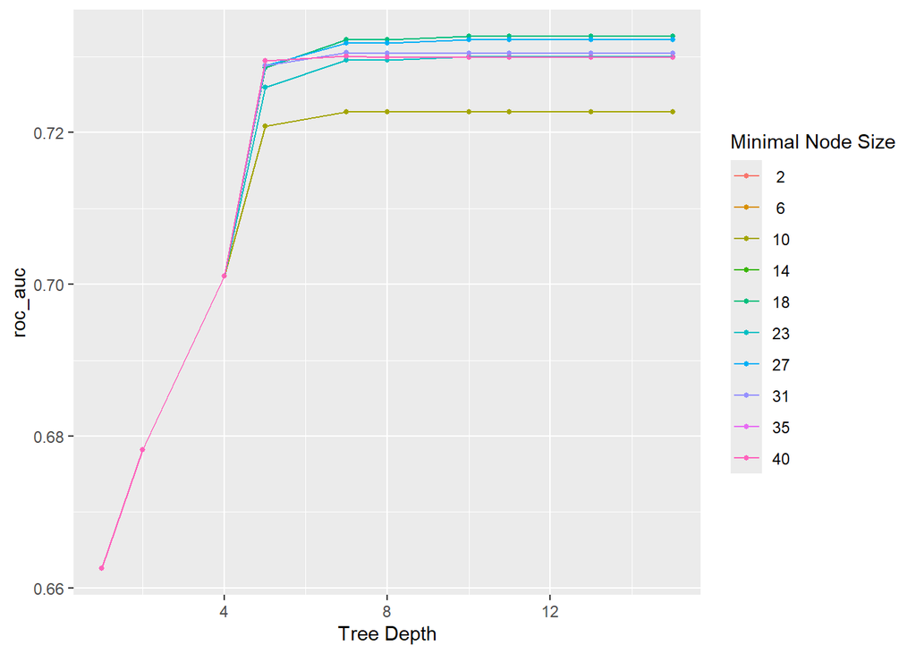

```r
library(rpart)
library(rpart.plot)
library(pROC)
set.seed(123)
decision_tree <- decision_tree(
                          cost_complexity = 0.02,
                          tree_depth = tune(),
                          min_n = tune()
                                        ) %>%
                          set_mode("classification") %>%
                          set_engine(engine = "rpart",
                                     parms = list(split = "information"))

tree_recipe <- recipe(data = train, formula = diabetes~.)

tree_workflow <- workflow() %>%
                  add_recipe(tree_recipe) %>%
                  add_model(decision_tree)

tree_parameters_grid <- grid_regular(parameters(decision_tree), levels = 10)

tree_tune_process <- tune_grid(tree_workflow,
                          resamples = folds,
                          grid = tree_parameters_grid,
                          metrics = metric_set(roc_auc))

autoplot(tree_tune_process)
```

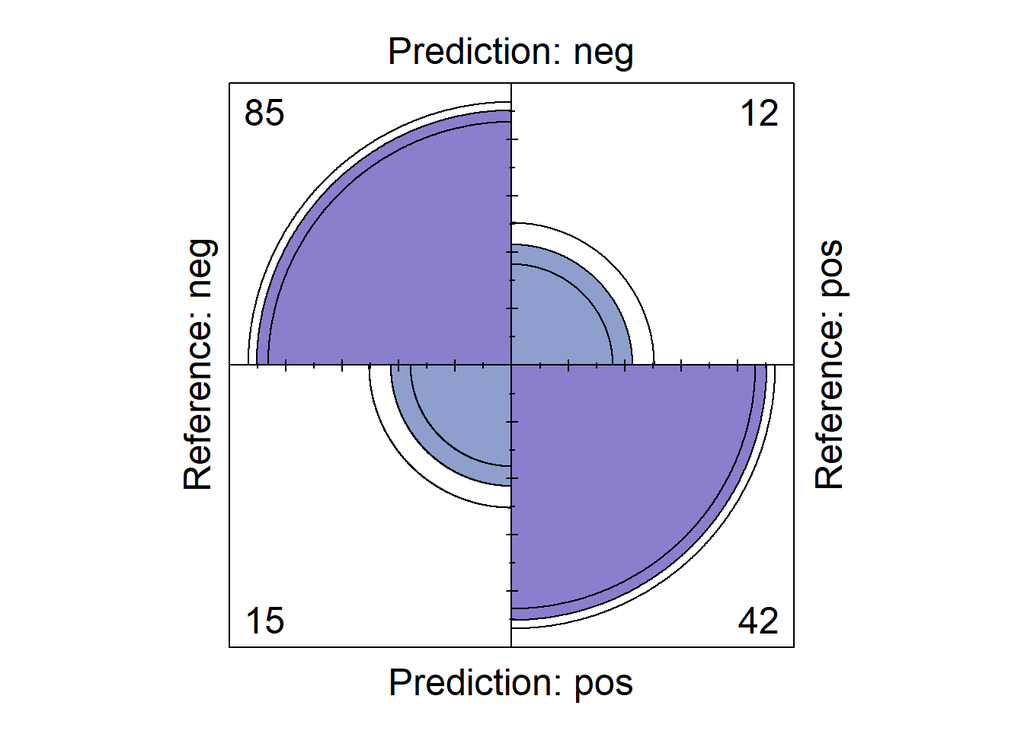

```r
tree_best_process <-  select_best(tree_tune_process, metric = 'roc_auc')

best_tree <- finalize_model(decision_tree, tree_best_process)
best_tree
Decision Tree Model Specification (classification)

Main Arguments:
  cost_complexity = 0.02
  tree_depth = 10
  min_n = 14

Engine-Specific Arguments:
  parms = list(split = "information")

Computational engine: rpart

resamples_fit <- fit_resamples(best_tree, diabetes ~ .,
                               resamples = folds)
collect_metrics(resamples_fit)
# A tibble: 3 × 6
  .metric     .estimator  mean     n std_err .config
  <chr>       <chr>      <dbl> <int>   <dbl> <chr>
1 accuracy    binary     0.736     5  0.0222 Preprocessor1_Model1
2 brier_class binary     0.191     5  0.0113 Preprocessor1_Model1
3 roc_auc     binary     0.733     5  0.0242 Preprocessor1_Model1

tree_best_fit <- fit(best_tree, diabetes~., train)
tree_best_fit
parsnip model object

n= 614

node), split, n, loss, yval, (yprob)
      * denotes terminal node

 1) root 614 214 neg (0.65146580 0.34853420)
   2) glucose< 154.5 517 135 neg (0.73887814 0.26112186)
     4) mass< 26.35 106   3 neg (0.97169811 0.02830189) *
     5) mass>=26.35 411 132 neg (0.67883212 0.32116788)
      10) glucose< 107.5 170  27 neg (0.84117647 0.15882353) *
      11) glucose>=107.5 241 105 neg (0.56431535 0.43568465)
        22) age< 30.5 126  39 neg (0.69047619 0.30952381) *
        23) age>=30.5 115  49 pos (0.42608696 0.57391304)
          46) triceps< 17.5 8   1 neg (0.87500000 0.12500000) *
          47) triceps>=17.5 107  42 pos (0.39252336 0.60747664) *
   3) glucose>=154.5 97  18 pos (0.18556701 0.81443299) *

tree_pred.classes <- predict(tree_best_fit, test, type = "class")
tree_pred.classes <- factor(unlist(tree_pred.classes))
tree_confusion_matrix <- confusionMatrix(data = tree_pred.classes,
                                         reference = test$diabetes,
                                         positive = "pos")

tree_confusion_matrix
Confusion Matrix and Statistics

          Reference
Prediction neg pos
       neg  85  12
       pos  15  42

               Accuracy : 0.8247
                 95% CI : (0.7553, 0.8812)
    No Information Rate : 0.6494
    P-Value [Acc > NIR] : 1.198e-06

                  Kappa : 0.6199

 Mcnemar's Test P-Value : 0.7003

            Sensitivity : 0.7778
            Specificity : 0.8500
         Pos Pred Value : 0.7368
         Neg Pred Value : 0.8763
             Prevalence : 0.3506
         Detection Rate : 0.2727
   Detection Prevalence : 0.3701
      Balanced Accuracy : 0.8139

       'Positive' Class : pos


fourfoldplot(tree_confusion_matrix$table, color = c("#8F9FCD", "#8A7FCD"))
```

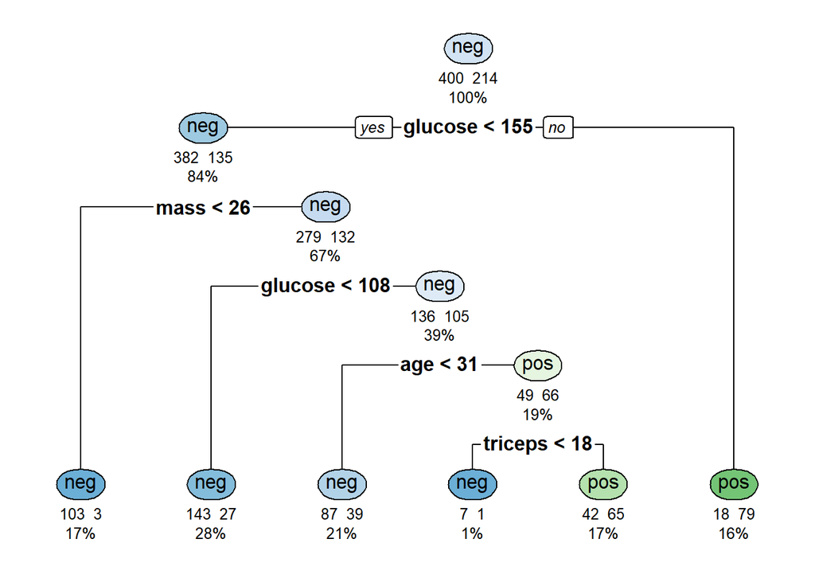

```r
rpart.plot(tree_best_fit$fit, extra = 101, under = TRUE, box.palette = "auto",
           tweak = 1.20, roundint = FALSE)
```

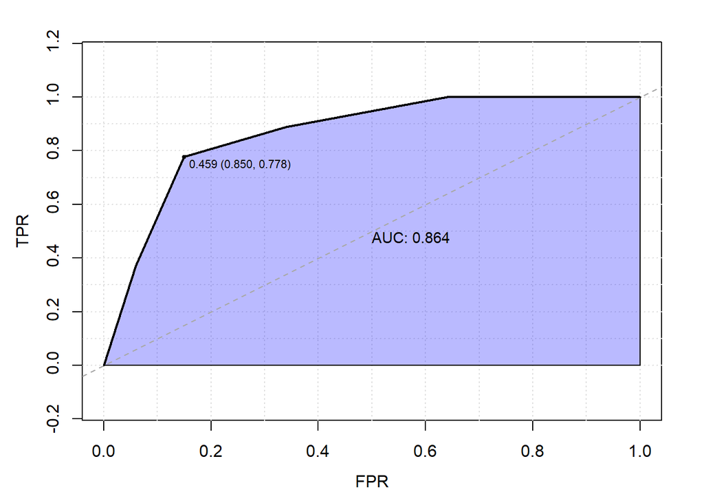

```r
tree_probabilities <- predict(tree_best_fit, test, type = "prob")
tree_curve <- roc(test$diabetes, tree_probabilities$.pred_pos)
plot.roc(tree_curve, print.auc = TRUE, auc.polygon = TRUE, asp = 0.50,
         grid = TRUE, identity.lty = 2, identity.lwd = 1, print.thres = TRUE,
         auc.polygon.col= rgb(0.1,0.1,1, alpha = 0.3), legacy.axes = TRUE,
         xlab = "FPR", ylab = "TPR", print.thres.cex = 0.7,
         print.auc.cex = 0.9)
```

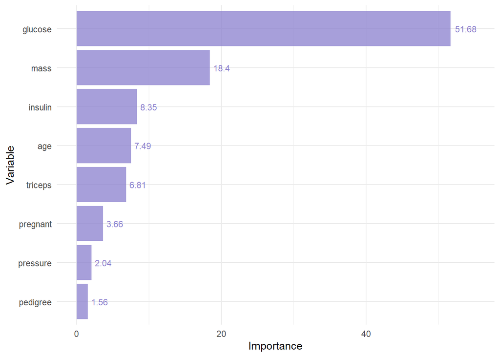

```r
tree_auc <- auc(tree_curve)
"AUC" -> names(tree_auc)
tree_accuracy <- tree_confusion_matrix$overall['Accuracy']
tree_sensitivity <- tree_confusion_matrix$byClass['Sensitivity']
tree_specificity <- tree_confusion_matrix$byClass['Specificity']
tree_precision <- tree_confusion_matrix$byClass[5]
tree_performance_metrics <- c(tree_auc, tree_accuracy, tree_sensitivity,
                              tree_specificity,
                              tree_precision)

tree_performance_metrics
        AUC    Accuracy Sensitivity Specificity   Precision
  0.8644444   0.8246753   0.7777778   0.8500000   0.7368421

tree_Var_Importance <- tree_best_fit$fit$variable.importance
tree_Var_Importance <- (tree_Var_Importance/sum(tree_Var_Importance))*100
tree_Var_Importance <- data.frame(tree_Var_Importance)
tree_Var_Importance <- data.frame(Variable =rownames(tree_Var_Importance),
                                  Importance = tree_Var_Importance$tree_Var_Importance)

ggplot(tree_Var_Importance, aes(x = Importance, y = reorder(Variable, Importance))) +
  geom_bar(stat = "identity", fill = "#8A7FCD", alpha = 0.75) +
  geom_text(aes(label = round(Importance, 2)), size = 3,
            hjust = -0.2, color = "#8A7FCD") +
  labs(x = "Importance", y = "Variable") +
  xlim(0,55) +
  theme_minimal()
```

- Balanced/Oversampled approach

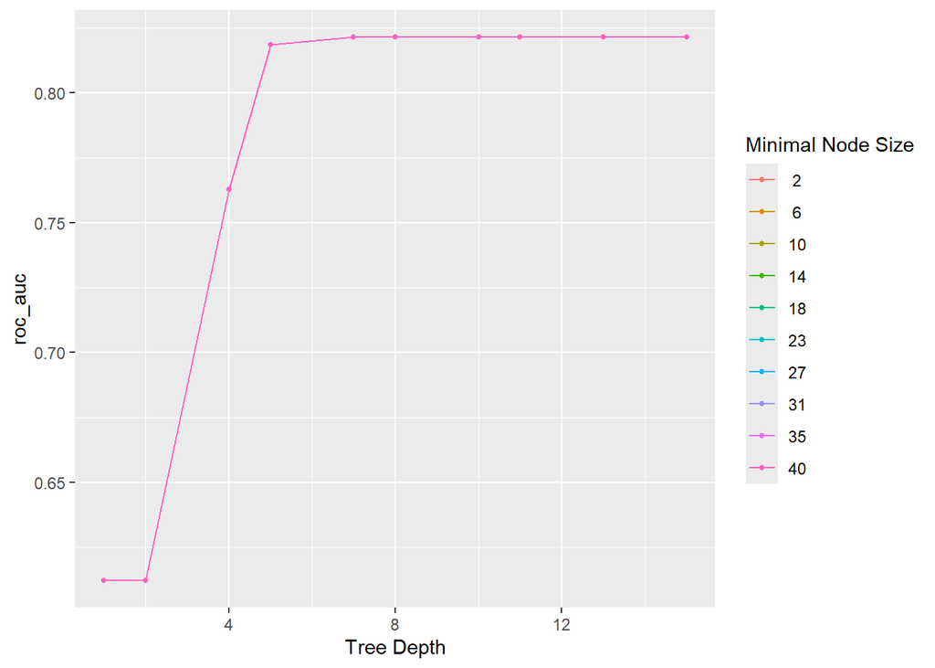

```r
library(rpart)
library(rpart.plot)
library(pROC)
set.seed(123)
balanced_decision_tree <- decision_tree(
                          cost_complexity = 0.02,
                          tree_depth = tune(),
                          min_n = tune()
                                        ) %>%
                          set_mode("classification") %>%
                          set_engine(engine = "rpart",
                                     parms = list(split = "information"))

balanced_tree_recipe <- recipe(data = balanced_train, formula = diabetes~.)

balanced_tree_workflow <- workflow() %>%
                  add_recipe(balanced_tree_recipe) %>%
                  add_model(balanced_decision_tree)

balanced_tree_parameters_grid <- grid_regular(parameters(balanced_decision_tree), levels = 10)

balanced_tree_tune_process <- tune_grid(balanced_tree_workflow,
                          resamples = balanced_folds,
                          grid = balanced_tree_parameters_grid,
                          metrics = metric_set(roc_auc))

autoplot(balanced_tree_tune_process)
```

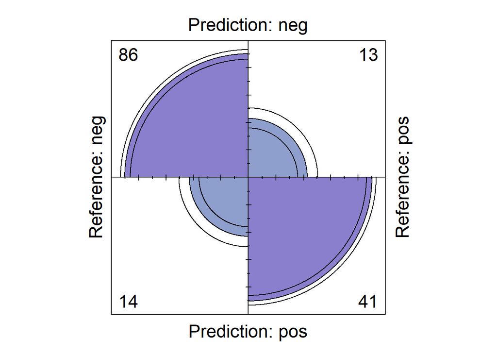

```r
balanced_tree_best_process <-  select_best(balanced_tree_tune_process, metric = 'roc_auc')

balanced_best_tree <- finalize_model(balanced_decision_tree, balanced_tree_best_process)
balanced_best_tree
Decision Tree Model Specification (classification)

Main Arguments:
  cost_complexity = 0.02
  tree_depth = 7
  min_n = 2

Engine-Specific Arguments:
  parms = list(split = "information")

Computational engine: rpart

balanced_resamples_fit <- fit_resamples(balanced_best_tree, diabetes ~ .,
                               resamples = balanced_folds)
collect_metrics(balanced_resamples_fit)
# A tibble: 3 × 6
  .metric     .estimator  mean     n std_err .config
  <chr>       <chr>      <dbl> <int>   <dbl> <chr>
1 accuracy    binary     0.756     5 0.0145  Preprocessor1_Model1
2 brier_class binary     0.171     5 0.00710 Preprocessor1_Model1
3 roc_auc     binary     0.822     5 0.0119  Preprocessor1_Model1

balanced_tree_best_fit <- fit(balanced_best_tree, diabetes~., balanced_train)
balanced_tree_best_fit
parsnip model object

n= 811

node), split, n, loss, yval, (yprob)
      * denotes terminal node

 1) root 811 400 pos (0.4932182 0.5067818)
   2) mass< 26.35 119  12 neg (0.8991597 0.1008403) *
   3) mass>=26.35 692 293 pos (0.4234104 0.5765896)
     6) pedigree< 1.837 624 293 pos (0.4695513 0.5304487)
      12) glucose< 106.2059 170  33 neg (0.8058824 0.1941176) *
      13) glucose>=106.2059 454 156 pos (0.3436123 0.6563877)
        26) glucose< 154.0412 331 142 pos (0.4290030 0.5709970)
          52) age< 30.15077 156  64 neg (0.5897436 0.4102564) *
          53) age>=30.15077 175  50 pos (0.2857143 0.7142857) *
        27) glucose>=154.0412 123  14 pos (0.1138211 0.8861789) *
     7) pedigree>=1.837 68   0 pos (0.0000000 1.0000000) *

balanced_tree_pred.classes <- predict(balanced_tree_best_fit, test, type = "class")
balanced_tree_pred.classes <- factor(unlist(balanced_tree_pred.classes))
balanced_tree_confusion_matrix <- confusionMatrix(data = balanced_tree_pred.classes,
                                         reference = test$diabetes,
                                         positive = "pos")

balanced_tree_confusion_matrix
Confusion Matrix and Statistics

          Reference
Prediction neg pos
       neg  86  13
       pos  14  41

               Accuracy : 0.8247
                 95% CI : (0.7553, 0.8812)
    No Information Rate : 0.6494
    P-Value [Acc > NIR] : 1.198e-06

                  Kappa : 0.6166

 Mcnemar's Test P-Value : 1

            Sensitivity : 0.7593
            Specificity : 0.8600
         Pos Pred Value : 0.7455
         Neg Pred Value : 0.8687
             Prevalence : 0.3506
         Detection Rate : 0.2662
   Detection Prevalence : 0.3571
      Balanced Accuracy : 0.8096

       'Positive' Class : pos


fourfoldplot(balanced_tree_confusion_matrix$table, color = c("#8F9FCD", "#8A7FCD"))
```

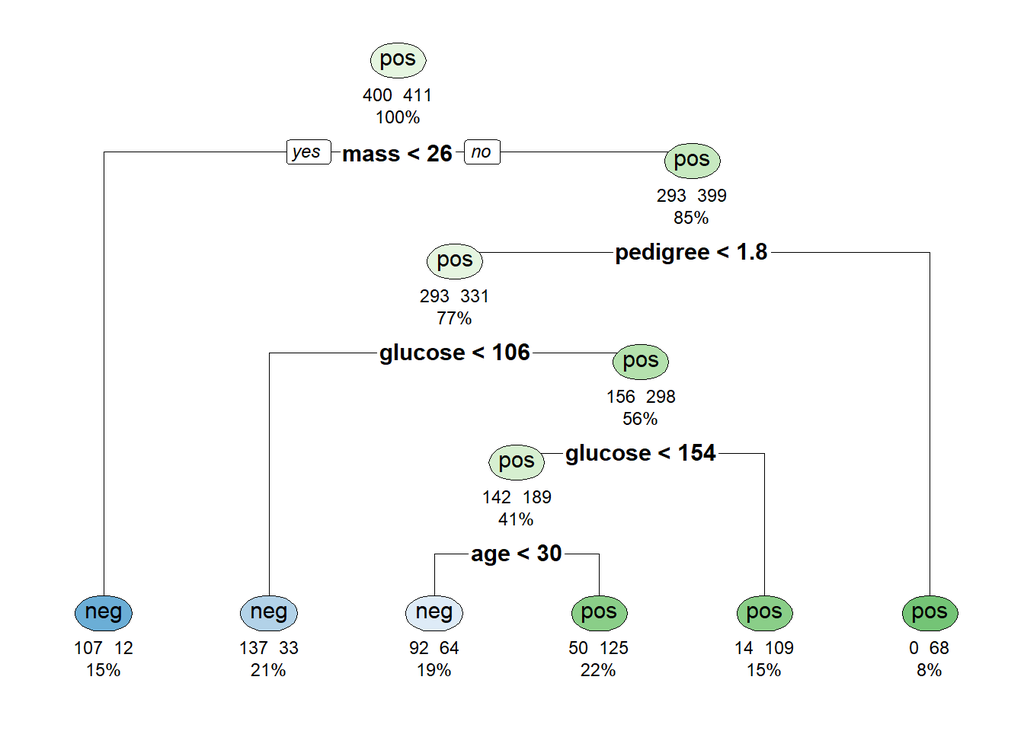

```r
rpart.plot(balanced_tree_best_fit$fit, extra = 101, under = TRUE, box.palette = "auto",
           tweak = 1.20, roundint = FALSE)
```

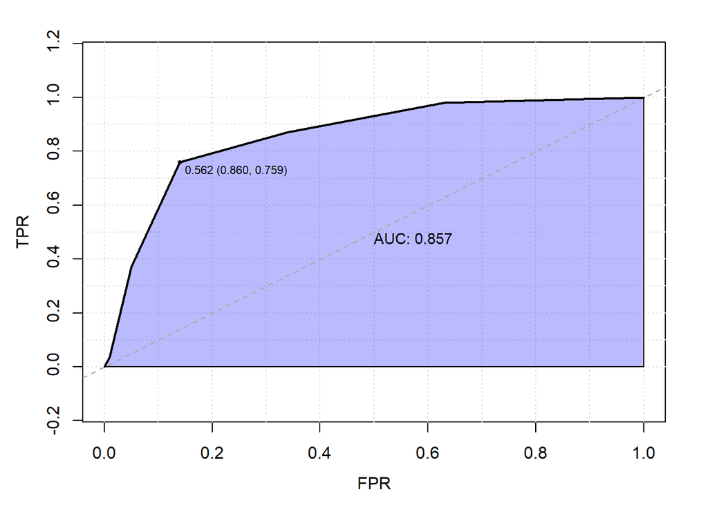

```r
balanced_tree_probabilities <- predict(balanced_tree_best_fit, test, type = "prob")
balanced_tree_curve <- roc(test$diabetes, balanced_tree_probabilities$.pred_pos)
plot.roc(balanced_tree_curve, print.auc = TRUE, auc.polygon = TRUE, asp = 0.50,
         grid = TRUE, identity.lty = 2, identity.lwd = 1, print.thres = TRUE,
         auc.polygon.col= rgb(0.1,0.1,1, alpha = 0.3), legacy.axes = TRUE,
         xlab = "FPR", ylab = "TPR", print.thres.cex = 0.7,
         print.auc.cex = 0.9)
```

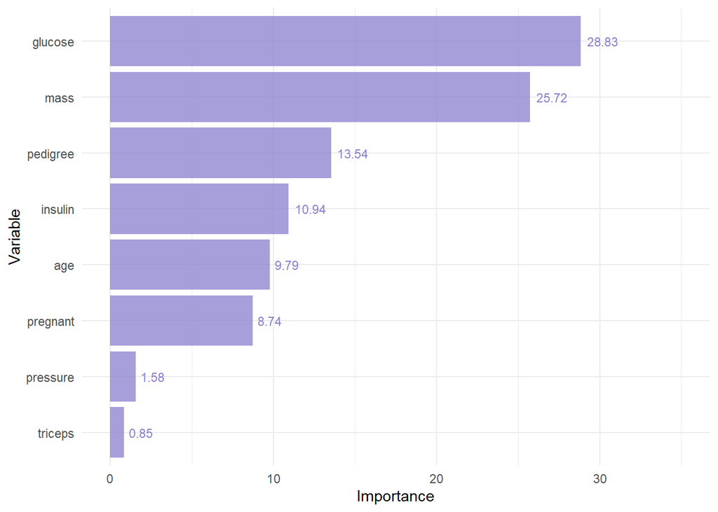

```r
balanced_tree_auc <- auc(balanced_tree_curve)
"AUC" -> names(balanced_tree_auc)
balanced_tree_accuracy <- balanced_tree_confusion_matrix$overall['Accuracy']
balanced_tree_sensitivity <- balanced_tree_confusion_matrix$byClass['Sensitivity']
balanced_tree_specificity <- balanced_tree_confusion_matrix$byClass['Specificity']
balanced_tree_precision <- balanced_tree_confusion_matrix$byClass[5]
balanced_tree_performance_metrics <- c(balanced_tree_auc, balanced_tree_accuracy,
balanced_tree_sensitivity, balanced_tree_specificity, balanced_tree_precision)

balanced_tree_performance_metrics
        AUC    Accuracy Sensitivity Specificity   Precision
  0.8572222   0.8246753   0.7592593   0.8600000   0.7454545

balanced_tree_Var_Importance <- balanced_tree_best_fit$fit$variable.importance
balanced_tree_Var_Importance <- (balanced_tree_Var_Importance /
                                 sum(balanced_tree_Var_Importance))*100
balanced_tree_Var_Importance <- data.frame(balanced_tree_Var_Importance)
balanced_tree_Var_Importance <- data.frame(
                              Variable=rownames(balanced_tree_Var_Importance),
                              Importance =
                                balanced_tree_Var_Importance$balanced_tree_Var_Importance)

ggplot(balanced_tree_Var_Importance, aes(x = Importance, y = reorder(Variable, Importance))) +
  geom_bar(stat = "identity", fill = "#8A7FCD", alpha = 0.75) +
  geom_text(aes(label = round(Importance, 2)), size = 3,
            hjust = -0.2, color = "#8A7FCD") +
  labs(x = "Importance", y = "Variable") +
  xlim(0,35) +
  theme_minimal()
```

One last and very important thing to note has to do with the variability of the model’s performance. At the final step of Data Preparation, we split the data into training and test sets. We used the `set.seed()` function to make the results reproducible, and eliminate the effect of randomness in the data split which is more amplified by the fact that we work in a tiny dataset with just a few records. The randomness of cross-validation is also eliminated. We should expect that different data sets and data folds, will also lead to different results in the auto-tuning process for the hyperparameters of the model, and this also contributes, in the variability of the final model. Not choosing the `set.seed()` will result in models with variability in their performance. For example, you may end up with a model, having the AUC metric in a value-range from approximately 0.70 up to 0.85 (at least those were my results in multiple runs I performed). Note that this randomness leads also to variability in the final interpretation of the model when you extract the importance of the predictors on the formation of the target variable. This is also the reason why we get a model that performs much better on the evaluation set than on the folds of the train set. Choosing a different `set.seed()`, can lead us to a model which does not generalize very well on ‘unseen’ data. This is probably one of the disadvantages of decision trees. The high variance on the resulting models. This effect of model variability is what we will try to mitigate in our next modelling attempt, where we shall use an ensemble of multiple trees. A statistical method known as Bootstrap aggregating. Bagged trees are an ensemble of decision trees, where the final tree is the result of their combination. As you can imagine Bagged trees, by averaging predictions from multiple trees trained on different subsets of the data, tend to reduce variability in the final model performance, compared to individual decision trees.

### Bagged Decision Trees

[Bagged decision trees](https://en.wikipedia.org/wiki/Bootstrap_aggregating), or Bootstrap Aggregated Trees, is an ensemble learning technique that combines the predictions of multiple decision trees to enhance predictive accuracy and reduce variance. Using bootstrap sampling, multiple decision trees with identical configuration are trained on different subsets of the data, with their predictions being aggregated to produce a final output.  
This data variation used in the ensemble makes the model more robust to unseen data and can generalize better than a single decision tree. As an aggregation of multiple decision trees, the final output of this ensemble is no longer a single tree, and thus its complexity cannot be easily interpreted. However, this is of no concern, since the main goal of bagged trees is to improve the performance of the model, reduce its variability and make it more robust. For the implementation of our bagged tree model, we shall set the number of decision trees to grow, to 100, while keeping the complexity parameter(cp) fixed at 0.02. We also set the tree depth at 5, to avoid increasing the complexity of the model and therefore mitigate the effect of ‘overfitting’ to a reasonable extent.

- Original/Unbalanced approach

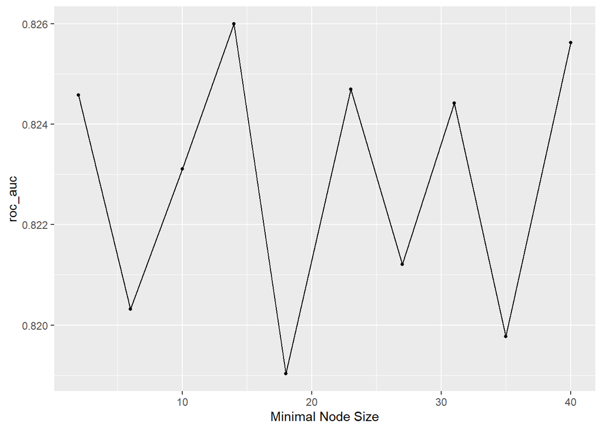

```r
library(baguette)
set.seed(123)
bag_tree <- bag_tree(
                     min_n = tune(),
                     tree_depth = 5,
                     cost_complexity = 0.02,
                                        ) %>%
                      set_engine('rpart', times = 100,
                                 parms = list(split = 'information')) %>%
                      set_mode('classification')

bag_recipe <- recipe(data = train, formula = diabetes~.)

bag_parameters_grid <- grid_regular(parameters(bag_tree), levels = 10)

bag_workflow <- workflow() %>%
                add_recipe(bag_recipe) %>%
                add_model(bag_tree)

bag_tune_process <- tune_grid(bag_workflow,
                               resamples = folds,
                               grid = bag_parameters_grid,
                               metrics = metric_set(roc_auc))

autoplot(bag_tune_process)
```

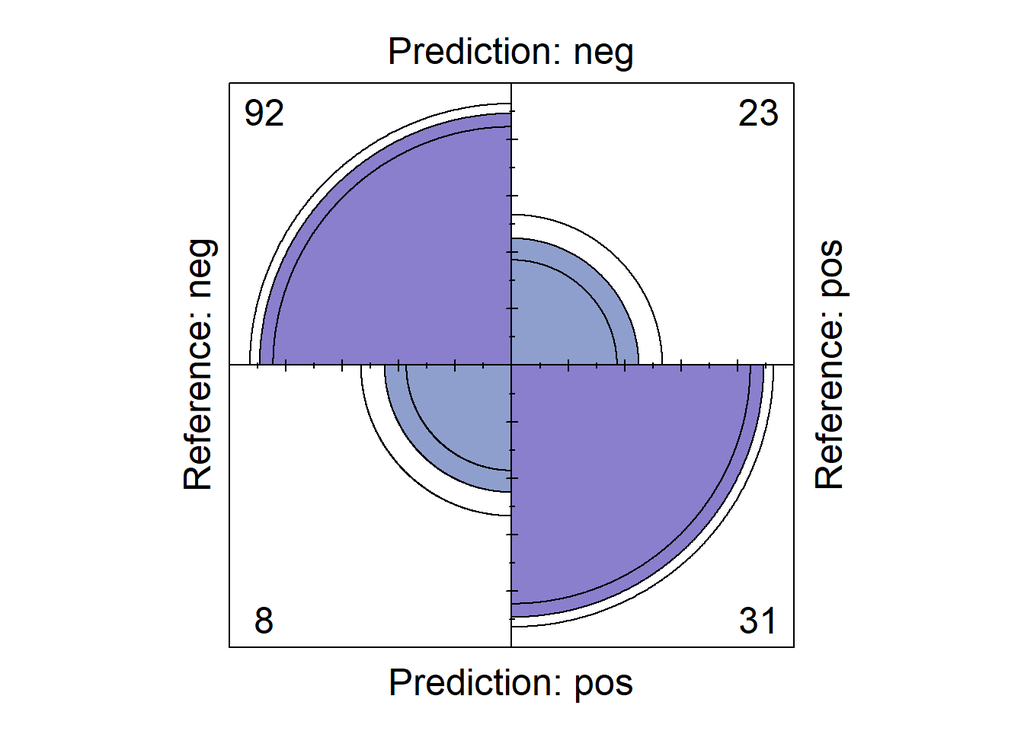

```r
bag_best_process <- select_best(bag_tune_process, metric = 'roc_auc')
best_bag <- finalize_model(bag_tree, bag_best_process)
best_bag
Bagged Decision Tree Model Specification (classification)

Main Arguments:
  cost_complexity = 0.02
  tree_depth = 5
  min_n = 14

Engine-Specific Arguments:
  times = 100
  parms = list(split = "information")

Computational engine: rpart

resamples_fit <- fit_resamples(best_bag, diabetes ~ .,
                               resamples = folds)
collect_metrics(resamples_fit)
# A tibble: 3 × 6
  .metric     .estimator  mean     n std_err .config
  <chr>       <chr>      <dbl> <int>   <dbl> <chr>
1 accuracy    binary     0.741     5 0.0148  Preprocessor1_Model1
2 brier_class binary     0.166     5 0.00769 Preprocessor1_Model1
3 roc_auc     binary     0.821     5 0.0149  Preprocessor1_Model1

bag_best_fit <- fit(best_bag, diabetes~., train)
bag_best_fit
parsnip model object

Bagged CART (classification with 100 members)

Variable importance scores include:

# A tibble: 8 × 4
  term     value std.error  used
  <chr>    <dbl>     <dbl> <int>
1 glucose  78.7      1.49    100
2 insulin  24.4      1.12    100
3 mass     24.1      1.28     96
4 age      16.0      1.06     91
5 pressure  8.61     0.626    94
6 triceps   8.22     0.594    91
7 pedigree  7.43     0.677    93
8 pregnant  6.40     0.649    81

bag_pred.classes <- predict(bag_best_fit, test, type = "class")
bag_pred.classes <- factor(unlist(bag_pred.classes))
bag_confusion_matrix <- confusionMatrix(data = bag_pred.classes,
                                reference =  test$diabetes, positive = "pos")
bag_confusion_matrix
Confusion Matrix and Statistics

          Reference
Prediction neg pos
       neg  92  23
       pos   8  31

               Accuracy : 0.7987
                 95% CI : (0.7266, 0.8589)
    No Information Rate : 0.6494
    P-Value [Acc > NIR] : 3.76e-05

                  Kappa : 0.5278

 Mcnemar's Test P-Value : 0.01192

            Sensitivity : 0.5741
            Specificity : 0.9200
         Pos Pred Value : 0.7949
         Neg Pred Value : 0.8000
             Prevalence : 0.3506
         Detection Rate : 0.2013
   Detection Prevalence : 0.2532
      Balanced Accuracy : 0.7470

       'Positive' Class : pos


fourfoldplot(bag_confusion_matrix$table, color = c("#8F9FCD", "#8A7FCD"))
```

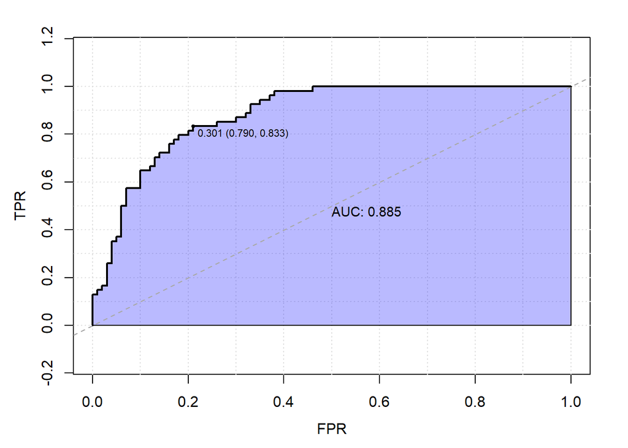

```r
bag_probabilities <- predict(bag_best_fit, test, type = "prob")
bag_curve <- roc(test$diabetes, bag_probabilities$.pred_pos)
plot.roc(bag_curve, print.auc = TRUE, auc.polygon = TRUE, asp = 0.50,
         grid = TRUE, identity.lty = 2, identity.lwd = 1, print.thres = TRUE,
         auc.polygon.col= rgb(0.1,0.1,1, alpha = 0.3), legacy.axes = TRUE,
         xlab = "FPR", ylab = "TPR", print.thres.cex = 0.7,
         print.auc.cex = 0.9)
```

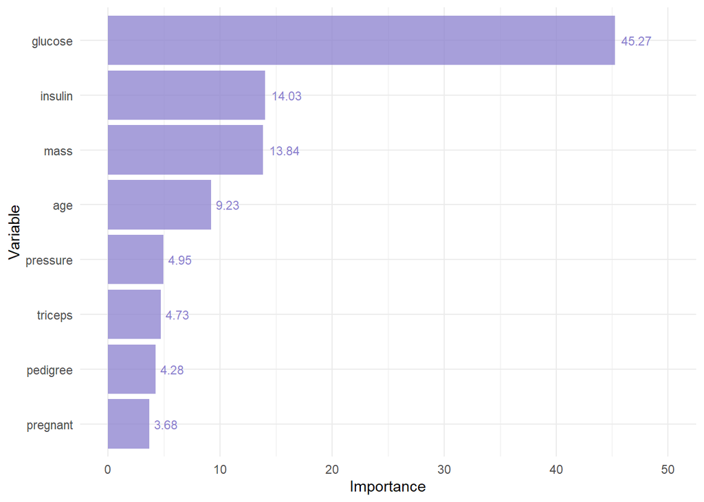

```r
bag_auc <- auc(bag_curve)
"bag_AUC" -> names(bag_auc)
bag_accuracy <- bag_confusion_matrix$overall['Accuracy']
bag_sensitivity <- bag_confusion_matrix$byClass['Sensitivity']
bag_specificity <- bag_confusion_matrix$byClass['Specificity']
bag_precision <- bag_confusion_matrix$byClass[5]
bag_performance_metrics <- c(bag_auc, bag_accuracy, bag_sensitivity,
                             bag_specificity,
                              bag_precision)

bag_performance_metrics
    bag_AUC    Accuracy Sensitivity Specificity   Precision
  0.8846296   0.7987013   0.5740741   0.9200000   0.7948718

bag_Var_Imp <- bag_best_fit$fit$imp[, 1:2]
bag_Var_Imp$value <- (bag_Var_Imp$value/
                             sum(bag_Var_Imp$value))*100

ggplot(bag_Var_Imp, aes(x = value, y =  reorder(term, value))) +
  geom_bar(stat = "identity", fill = "#8A7FCD", alpha = 0.75) +
  geom_text(aes(label = round(value, 2)), size = 3,
            hjust = -0.2, color = "#8A7FCD") +
  labs(x = "Importance", y = "Variable") +
  xlim(0,50) +
  theme_minimal()
```

- Balanced/Oversampled approach

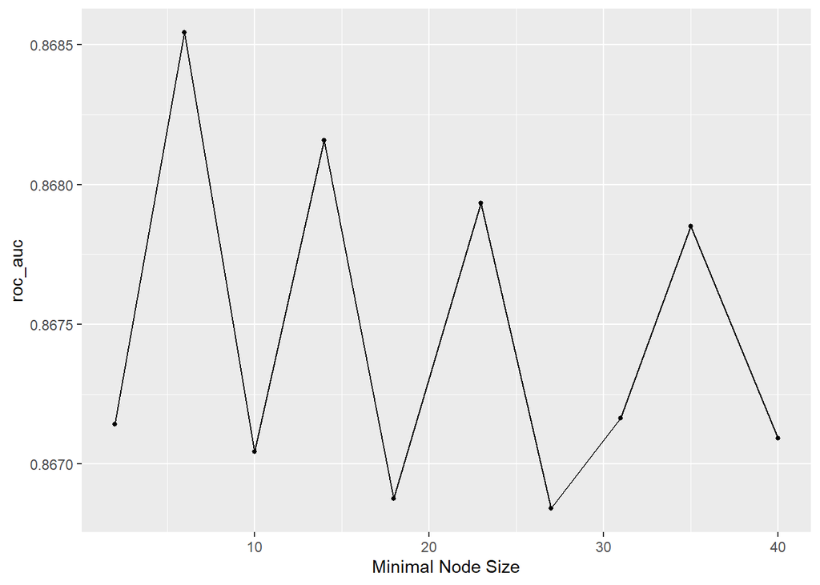

```r
library(baguette)
set.seed(123)
balanced_bag_tree <- bag_tree(
                     min_n = tune(),
                     tree_depth = 5,
                     cost_complexity = 0.02,
                                        ) %>%
                      set_engine('rpart', times = 100,
                                 parms = list(split = 'information')) %>%
                      set_mode('classification')

balanced_bag_recipe <- recipe(data = balanced_train, formula = diabetes~.)

balanced_bag_parameters_grid <- grid_regular(parameters(balanced_bag_tree), levels = 10)

balanced_bag_workflow <- workflow() %>%
                add_recipe(balanced_bag_recipe) %>%
                add_model(balanced_bag_tree)

balanced_bag_tune_process <- tune_grid(balanced_bag_workflow,
                               resamples = balanced_folds,
                               grid = balanced_bag_parameters_grid,
                               metrics = metric_set(roc_auc))

autoplot(balanced_bag_tune_process)
```

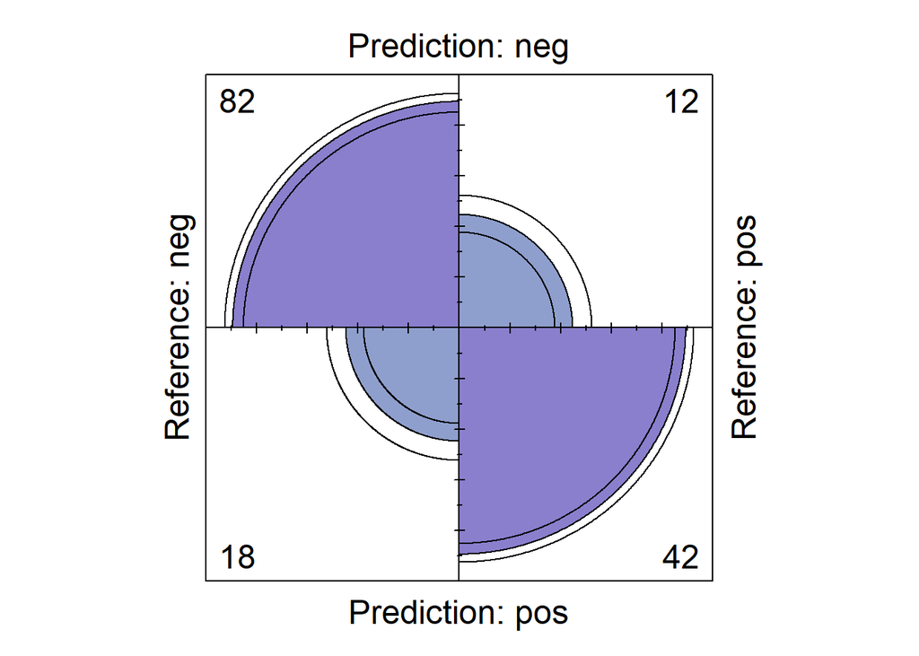

```r
balanced_bag_best_process <- select_best(balanced_bag_tune_process, metric = 'roc_auc')
balanced_best_bag <- finalize_model(balanced_bag_tree, balanced_bag_best_process)
balanced_best_bag
Bagged Decision Tree Model Specification (classification)

Main Arguments:
  cost_complexity = 0.02
  tree_depth = 5
  min_n = 6

Engine-Specific Arguments:
  times = 100
  parms = list(split = "information")

Computational engine: rpart

balanced_resamples_fit <- fit_resamples(balanced_best_bag, diabetes ~ .,
                               resamples = balanced_folds)
collect_metrics(balanced_resamples_fit)
# A tibble: 3 × 6
  .metric     .estimator  mean     n std_err .config
  <chr>       <chr>      <dbl> <int>   <dbl> <chr>
1 accuracy    binary     0.782     5 0.0118  Preprocessor1_Model1
2 brier_class binary     0.151     5 0.00360 Preprocessor1_Model1
3 roc_auc     binary     0.867     5 0.00738 Preprocessor1_Model1

balanced_bag_best_fit <- fit(balanced_best_bag, diabetes~., balanced_train)
balanced_bag_best_fit
parsnip model object

Bagged CART (classification with 100 members)

Variable importance scores include:

# A tibble: 8 × 4
  term     value std.error  used
  <chr>    <dbl>     <dbl> <int>
1 glucose  93.5      2.28    100
2 mass     85.9      1.65    100
3 pedigree 52.1      1.41    100
4 insulin  39.0      1.50    100
5 age      38.8      1.81    100
6 pregnant 31.0      1.24    100
7 triceps  13.9      1.02    100
8 pressure  9.02     0.898    94

balanced_bag_pred.classes <- predict(balanced_bag_best_fit, test, type = "class")
balanced_bag_pred.classes <- factor(unlist(balanced_bag_pred.classes))
balanced_bag_confusion_matrix <- confusionMatrix(data = balanced_bag_pred.classes,
                                reference =  test$diabetes, positive = "pos")
balanced_bag_confusion_matrix
Confusion Matrix and Statistics

          Reference
Prediction neg pos
       neg  82  12
       pos  18  42

               Accuracy : 0.8052
                 95% CI : (0.7337, 0.8645)
    No Information Rate : 0.6494
    P-Value [Acc > NIR] : 1.687e-05

                  Kappa : 0.5829

 Mcnemar's Test P-Value : 0.3613

            Sensitivity : 0.7778
            Specificity : 0.8200
         Pos Pred Value : 0.7000
         Neg Pred Value : 0.8723
             Prevalence : 0.3506
         Detection Rate : 0.2727
   Detection Prevalence : 0.3896
      Balanced Accuracy : 0.7989

       'Positive' Class : pos


fourfoldplot(balanced_bag_confusion_matrix$table, color = c("#8F9FCD", "#8A7FCD"))
```

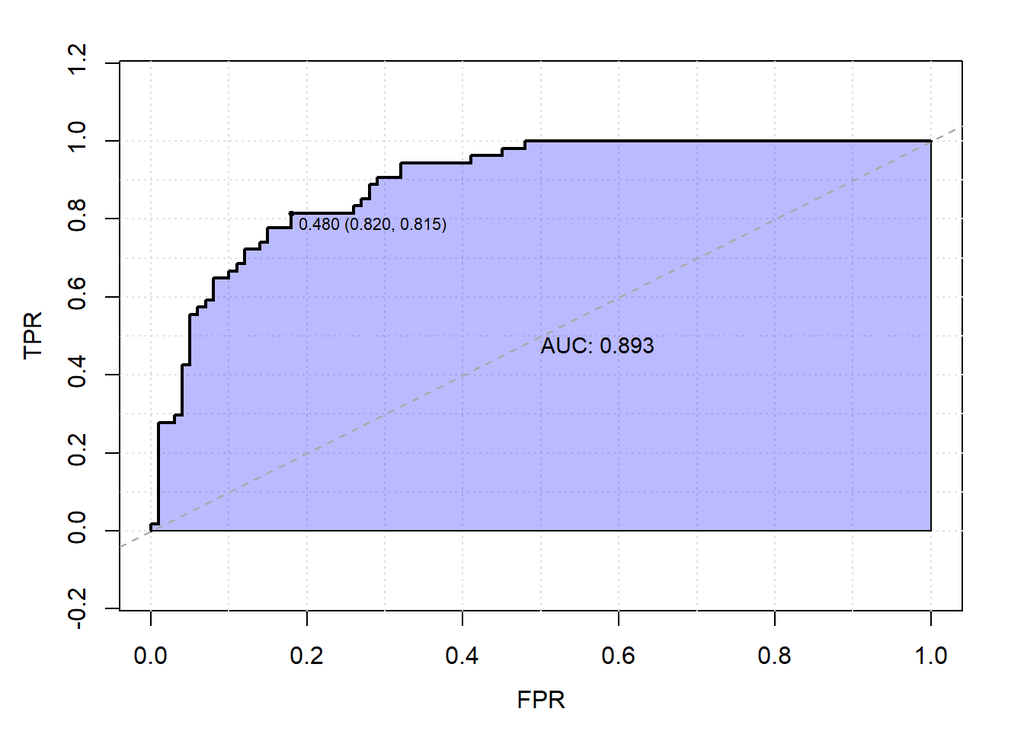

```r
balanced_bag_probabilities <- predict(balanced_bag_best_fit, test, type = "prob")
balanced_bag_curve <- roc(test$diabetes, balanced_bag_probabilities$.pred_pos)
plot.roc(balanced_bag_curve, print.auc = TRUE, auc.polygon = TRUE, asp = 0.50,
         grid = TRUE, identity.lty = 2, identity.lwd = 1, print.thres = TRUE,
         auc.polygon.col= rgb(0.1,0.1,1, alpha = 0.3), legacy.axes = TRUE,
         xlab = "FPR", ylab = "TPR", print.thres.cex = 0.7,
         print.auc.cex = 0.9)
```

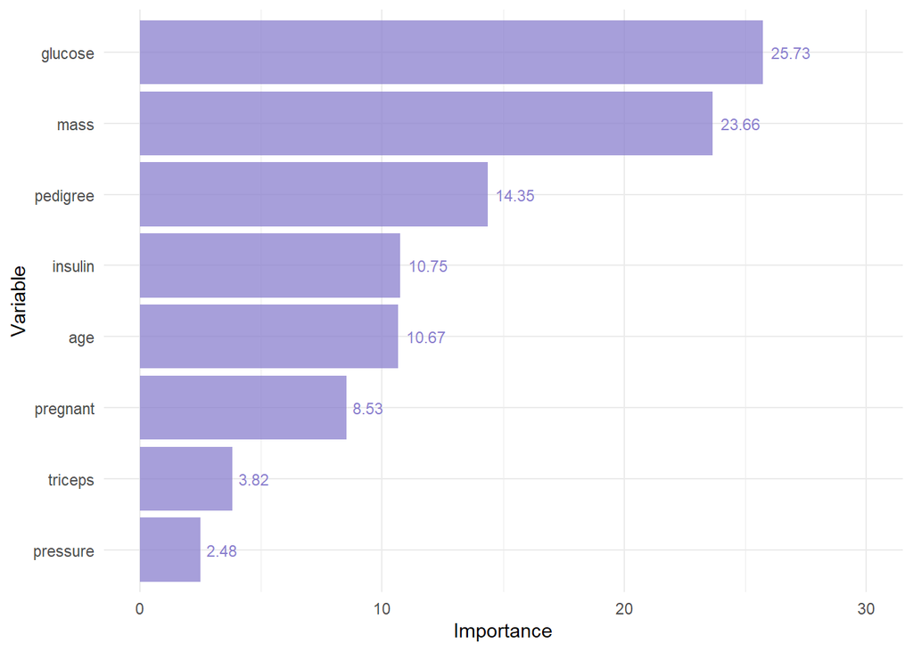

```r
balanced_bag_auc <- auc(balanced_bag_curve)
"bag_AUC" -> names(balanced_bag_auc)
balanced_bag_accuracy <- balanced_bag_confusion_matrix$overall['Accuracy']
balanced_bag_sensitivity <- balanced_bag_confusion_matrix$byClass['Sensitivity']
balanced_bag_specificity <- balanced_bag_confusion_matrix$byClass['Specificity']
balanced_bag_precision <- balanced_bag_confusion_matrix$byClass[5]
balanced_bag_performance_metrics <- c(balanced_bag_auc, balanced_bag_accuracy, balanced_bag_sensitivity, balanced_bag_specificity, balanced_bag_precision)

balanced_bag_performance_metrics
    bag_AUC    Accuracy Sensitivity Specificity   Precision
  0.8929630   0.8051948   0.7777778   0.8200000   0.7000000

balanced_bag_Var_Imp <- balanced_bag_best_fit$fit$imp[, 1:2]
balanced_bag_Var_Imp$value <- (balanced_bag_Var_Imp$value/
                             sum(balanced_bag_Var_Imp$value))*100

ggplot(balanced_bag_Var_Imp, aes(x = value, y =  reorder(term, value))) +
  geom_bar(stat = "identity", fill = "#8A7FCD", alpha = 0.75) +
  geom_text(aes(label = round(value, 2)), size = 3,
            hjust = -0.2, color = "#8A7FCD") +
  labs(x = "Importance", y = "Variable") +
  xlim(0,30) +
  theme_minimal()
```

### Random Forest

[Random Forest](https://www.stat.berkeley.edu/~breiman/RandomForests/cc_home.htm) is a special case of bagging trees. It is a powerful ensemble learning algorithm that combines the strengths of decision trees with the principles of bagging and feature subsampling. The forest consists of multiple decision trees that are built with the same settings, but this time during the ‘growing’ process of each individual tree, at every node the split process takes into account only a random subset of the predictors/features. Also, the datasets used for each tree are different from each other and come from a bootstrap sampling of the original training data.  
Therefore, the algorithm of Random Forests following this procedure achieves two important things at the same time. Firstly, the trees are de-correlated from each other and so the variability/variance is minimized, making the model more robust to unseen data and at the same time using different subsets of predictors in each step of the tree creation, the bias of the result is reduced, since it does not become heavily dependent to any specific set of predictors.  
We can set this manually via the ‘mtry’ parameter. The mtry parameter controls the number of predictors sampled at each split when building each tree in the forest. By limiting the number of predictors considered at each split, you can reduce the complexity of the trees and mitigate the effect of overfitting. A general rule of thumb for setting ‘mtry’ is the square root of the total number of predictors, and this is what we will use in our model also.  
In our case we will set ‘mtry’ to 3. This means, that at every node of the tree, 3 out of 8 total predictors, will be randomly selected for the splitting process. The maximum number of trees we can grow in the forest is 2000. However, in an attempt to reduce the computational costs, and the risk of overfitting the model, we will proceed with a forest of 500 trees.

- Original/Unbalanced approach

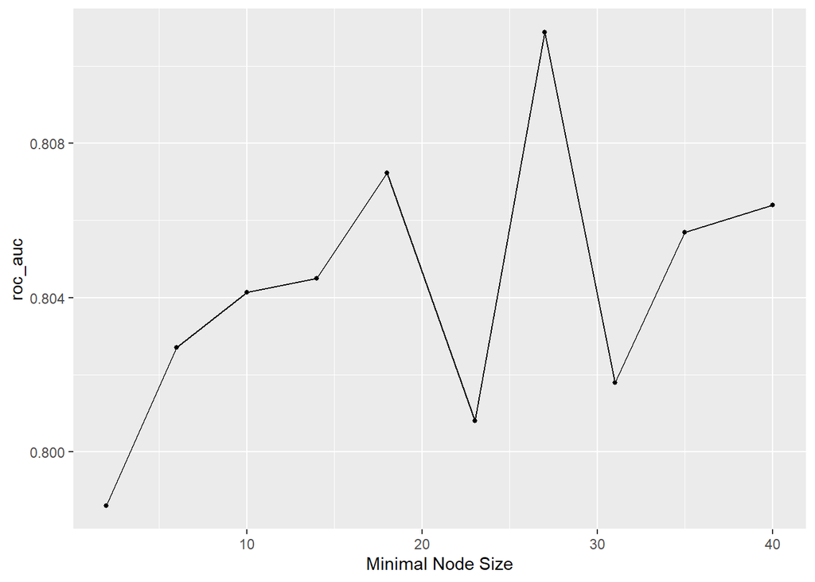

```r
library(ranger)
set.seed(123)
forest <- rand_forest(
                      mtry = 3,
                      trees = 500,
                      min_n = tune()
                                      ) %>%
                      set_engine("ranger", num.threads = 8,
                       splitrule = "gini", importance = "impurity_corrected") %>%
                      set_mode('classification')

forest_recipe <- recipe(data = train, formula = diabetes~.)

forest_parameters <- extract_parameter_set_dials(forest) %>%
                      finalize(train)

forest_grid <- grid_regular(forest_parameters$object, levels = 10)

forest_workflow <- workflow() %>%
                    add_recipe(forest_recipe) %>%
                    add_model(forest)

tune_forest <- tune_grid(forest_workflow,
                         resamples = folds,
                         grid = forest_grid,
                         metrics = metric_set(roc_auc))

autoplot(tune_forest)
```

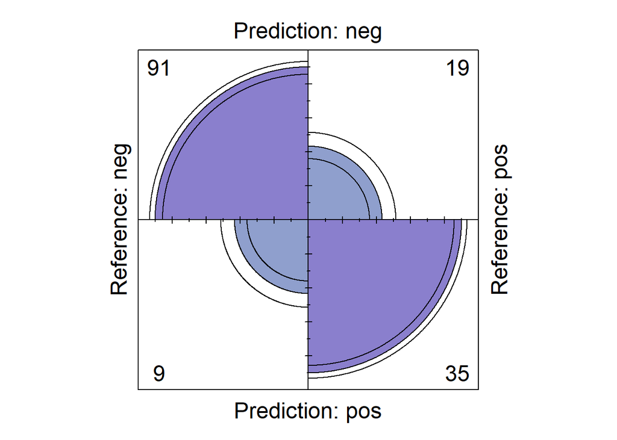

```r
forest_best_process <- select_best(tune_forest, metric = 'roc_auc')
best_forest <- finalize_model(forest, forest_best_process)
best_forest
Random Forest Model Specification (classification)

Main Arguments:
  mtry = 3
  trees = 500
  min_n = 27

Engine-Specific Arguments:
  num.threads = 8
  splitrule = gini
  importance = impurity_corrected

Computational engine: ranger

resamples_fit <- fit_resamples(best_forest, diabetes ~ .,
                               resamples = folds)
collect_metrics(resamples_fit)
# A tibble: 3 × 6
  .metric     .estimator  mean     n std_err .config
  <chr>       <chr>      <dbl> <int>   <dbl> <chr>
1 accuracy    binary     0.749     5 0.0185  Preprocessor1_Model1
2 brier_class binary     0.171     5 0.00634 Preprocessor1_Model1
3 roc_auc     binary     0.802     5 0.0182  Preprocessor1_Model1

forest_best_fit <- fit(best_forest, diabetes~., train)
forest_best_fit
parsnip model object

Ranger result

Call:
 ranger::ranger(x = maybe_data_frame(x), y = y, mtry = min_cols(~3,      x), num.trees = ~500, min.node.size = min_rows(~27L, x),      num.threads = ~8, splitrule = ~"gini", importance = ~"impurity_corrected",      verbose = FALSE, seed = sample.int(10^5, 1), probability = TRUE)

Type:                             Probability estimation
Number of trees:                  500
Sample size:                      614
Number of independent variables:  8
Mtry:                             3
Target node size:                 27
Variable importance mode:         impurity_corrected
Splitrule:                        gini
OOB prediction error (Brier s.):  0.1720055

forest_pred.classes <- predict(forest_best_fit, test, type = "class")
forest_pred.classes <- factor(unlist(forest_pred.classes))
forest_confusion_matrix <- confusionMatrix(forest_pred.classes, test$diabetes,
                                        positive = "pos")
forest_confusion_matrix
Confusion Matrix and Statistics

          Reference
Prediction neg pos
       neg  91  19
       pos   9  35

               Accuracy : 0.8182
                 95% CI : (0.7481, 0.8757)
    No Information Rate : 0.6494
    P-Value [Acc > NIR] : 3.015e-06

                  Kappa : 0.583

 Mcnemar's Test P-Value : 0.08897

            Sensitivity : 0.6481
            Specificity : 0.9100
         Pos Pred Value : 0.7955
         Neg Pred Value : 0.8273
             Prevalence : 0.3506
         Detection Rate : 0.2273
   Detection Prevalence : 0.2857
      Balanced Accuracy : 0.7791

       'Positive' Class : pos


fourfoldplot(forest_confusion_matrix$table, color = c("#8F9FCD", "#8A7FCD"))
```

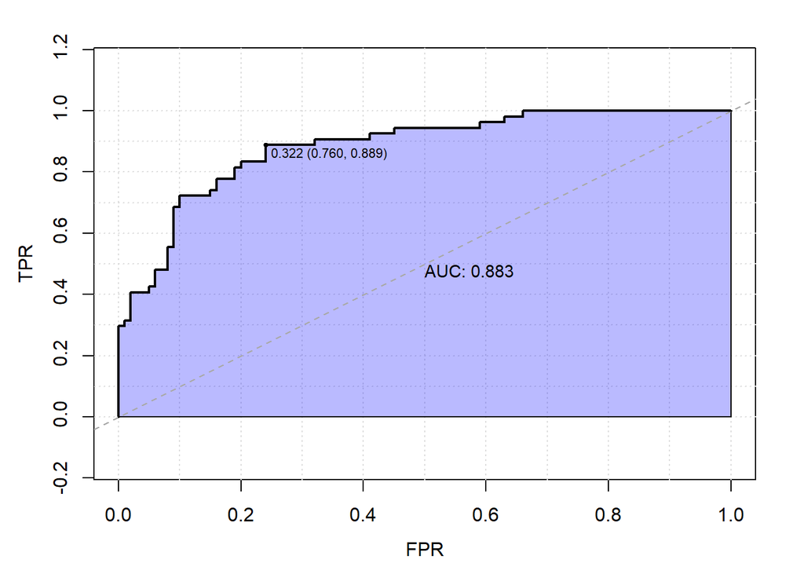

```r
forest_probabilities <- predict(forest_best_fit, test, type = "prob")
forest_curve <- roc(test$diabetes, forest_probabilities$.pred_pos)
plot.roc(forest_curve, print.auc = TRUE, auc.polygon = TRUE, asp = 0.50,
         grid = TRUE, identity.lty = 2, identity.lwd = 1, print.thres = TRUE,
         auc.polygon.col= rgb(0.1,0.1,1, alpha = 0.3), legacy.axes = TRUE,
         xlab = "FPR", ylab = "TPR", print.thres.cex = 0.7,
         print.auc.cex = 0.9)
```

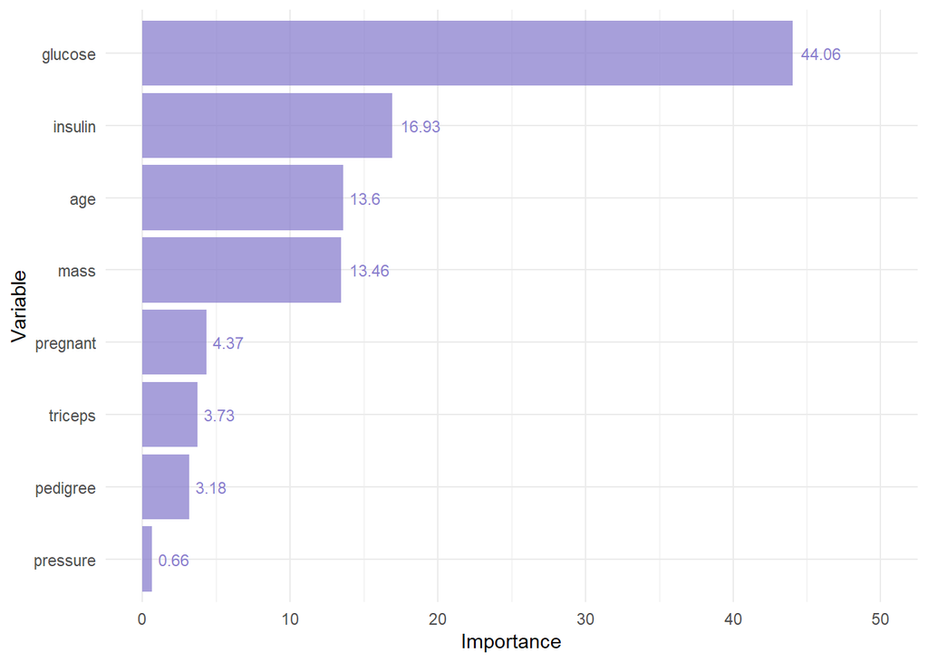

```r
forest_auc <- auc(forest_curve)
"forest_AUC" -> names(forest_auc)
forest_accuracy <- forest_confusion_matrix$overall['Accuracy']
forest_sensitivity <- forest_confusion_matrix$byClass['Sensitivity']
forest_specificity <- forest_confusion_matrix$byClass['Specificity']
forest_precision <- forest_confusion_matrix$byClass[5]
forest_performance_metrics <- c(forest_auc, forest_accuracy,
                                forest_sensitivity,
                                forest_specificity, forest_precision)

forest_performance_metrics
 forest_AUC    Accuracy Sensitivity Specificity   Precision
  0.8829630   0.8181818   0.6481481   0.9100000   0.7954545

forest_Var_Imp <- forest_best_fit$fit$variable.importance
forest_Var_Imp <- data.frame(forest_Var_Imp)
term <- rownames(forest_Var_Imp)
value <- forest_Var_Imp$forest_Var_Imp
forest_Var_Imp <- data.frame(term, value)

forest_Var_Imp$value <- (forest_Var_Imp$value/sum(forest_Var_Imp$value))*100

ggplot(forest_Var_Imp, aes(x = value, y =  reorder(term, value))) +
  geom_bar(stat = "identity", fill = "#8A7FCD", alpha = 0.75) +
  geom_text(aes(label = round(value, 2)), size = 3,
            hjust = -0.2, color = "#8A7FCD") +
  labs(x = "Importance", y = "Variable") +
  xlim(0,50) +
   theme_minimal()
```

- Balanced/Oversampled approach

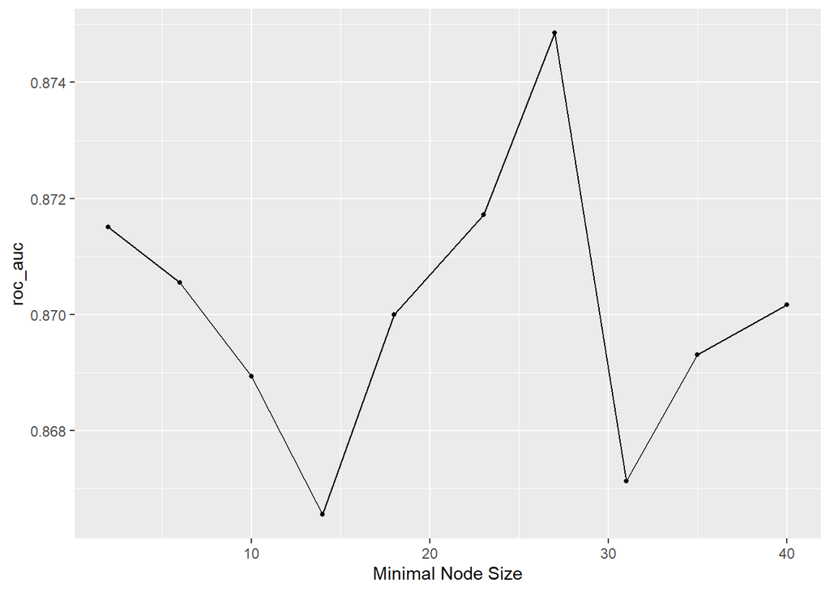

```r
library(ranger)
set.seed(123)
balanced_forest <- rand_forest(
                      mtry = 3,
                      trees = 500,
                      min_n = tune()
                                      ) %>%
                      set_engine("ranger", num.threads = 8,
                       splitrule = "gini", importance = "impurity_corrected") %>%
                      set_mode('classification')

balanced_forest_recipe <- recipe(data = balanced_train, formula = diabetes~.)

balanced_forest_parameters <- extract_parameter_set_dials(balanced_forest) %>%
                      finalize(balanced_train)

balanced_forest_grid <- grid_regular(balanced_forest_parameters$object, levels = 10)

balanced_forest_workflow <- workflow() %>%
                    add_recipe(balanced_forest_recipe) %>%
                    add_model(balanced_forest)

balanced_tune_forest <- tune_grid(balanced_forest_workflow,
                         resamples = balanced_folds,
                         grid = balanced_forest_grid,
                         metrics = metric_set(roc_auc))

autoplot(balanced_tune_forest)
```